```r
setwd('/media/jidde/Western Dig/analysis_backup_18_08_2021/levodopa project')
data <- readRDS("data_levodopa_29_01_21.rds")
```

Load Libraries

```r
library(ggplot2)
library(plyr)
library(dplyr)
library(lme4)
library(car)
library(lmerTest)
library(visreg)
```

Data wrangling

```r
data$Gender <- as.factor(data$Gender)
data$group[data$group=="CTRL"] <- "Typical"
```

# Statistic analysis

Write Cohens d function

```r
lme.dscore<-function(mod,data,type){
  if (type=="lme4") {
    mod1<-lmerTest::lmer(mod,data=data)
    eff<-cbind(summary(mod1)$coefficients[,4],summary(mod1)$coefficients[,3])
  }

  if (type=="nlme") {
    eff=cbind(summary(mod)$tTable[,4],summary(mod)$fixDF$terms)
  }

  colnames(eff)<-c("t","df")
  eff<-as.data.frame(eff)
  eff$d<-(2*eff$t)/sqrt(eff$df)
  eff<-eff[-1,]
  return(eff)
}
```

# Models for VSA

Base model

```r
summary(m0 <- lmer(VSA ~ (1|participant.id), data = data))
```

```
## Linear mixed model fit by REML. t-tests use Satterthwaite's method [
## lmerModLmerTest]
## Formula: VSA ~ (1 | participant.id)
##    Data: data
##
## REML criterion at convergence: 8134.7
##
## Scaled residuals:
##     Min      1Q  Median      3Q     Max
## -5.2121 -0.4753  0.0673  0.5464  2.1764
##
## Random effects:
##  Groups         Name        Variance  Std.Dev.
##  participant.id (Intercept) 1.752e+10 132368
##  Residual                   1.249e+09  35334
## Number of obs: 339, groups:  participant.id, 17
##
## Fixed effects:
##             Estimate Std. Error     df t value Pr(>|t|)
## (Intercept)   265804      32161     16   8.265 3.63e-07 ***
## ---
## Signif. codes:  0 '***' 0.001 '**' 0.01 '*' 0.05 '.' 0.1 ' ' 1
```

```r
summary(m0)
```

```
## Linear mixed model fit by REML. t-tests use Satterthwaite's method [
## lmerModLmerTest]
## Formula: VSA ~ (1 | participant.id)
##    Data: data
##
## REML criterion at convergence: 8134.7
##
## Scaled residuals:
##     Min      1Q  Median      3Q     Max
## -5.2121 -0.4753  0.0673  0.5464  2.1764
##
## Random effects:
##  Groups         Name        Variance  Std.Dev.
##  participant.id (Intercept) 1.752e+10 132368
##  Residual                   1.249e+09  35334
## Number of obs: 339, groups:  participant.id, 17
##
## Fixed effects:
##             Estimate Std. Error     df t value Pr(>|t|)
## (Intercept)   265804      32161     16   8.265 3.63e-07 ***
## ---
## Signif. codes:  0 '***' 0.001 '**' 0.01 '*' 0.05 '.' 0.1 ' ' 1
```

Model with gender as fixed effect & random intercepts for subjects

```r
summary(m1 <- lmer(VSA ~ Gender + (1|participant.id), data = data))
```

```
## Linear mixed model fit by REML. t-tests use Satterthwaite's method [
## lmerModLmerTest]
## Formula: VSA ~ Gender + (1 | participant.id)
##    Data: data
##
## REML criterion at convergence: 8090.3
##
## Scaled residuals:
##     Min      1Q  Median      3Q     Max
## -5.2465 -0.4926  0.0648  0.5496  2.1824
##
## Random effects:
##  Groups         Name        Variance  Std.Dev.
##  participant.id (Intercept) 4.763e+09 69013
##  Residual                   1.249e+09 35334
## Number of obs: 339, groups:  participant.id, 17
##
## Fixed effects:
##             Estimate Std. Error      df t value Pr(>|t|)
## (Intercept)   383398      24559      15  15.611 1.10e-10 ***
## Gendermale   -222124      33754      15  -6.581 8.72e-06 ***
## ---
## Signif. codes:  0 '***' 0.001 '**' 0.01 '*' 0.05 '.' 0.1 ' ' 1
##
## Correlation of Fixed Effects:
##            (Intr)
## Gendermale -0.728
```

```r
anova(m0, m1)
```

```
## refitting model(s) with ML (instead of REML)
```

```
## Data: data
## Models:
## m0: VSA ~ (1 | participant.id)
## m1: VSA ~ Gender + (1 | participant.id)
##    npar    AIC    BIC  logLik deviance Chisq Df Pr(>Chisq)
## m0    3 8163.3 8174.8 -4078.6   8157.3
## m1    4 8142.2 8157.5 -4067.1   8134.2 23.08  1  1.554e-06 ***
## ---
## Signif. codes:  0 '***' 0.001 '**' 0.01 '*' 0.05 '.' 0.1 ' ' 1
```

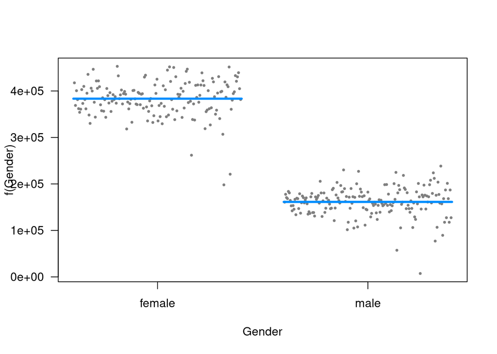

```r
visreg(m1)
```

Model with group and Gender as fixed & random intercepts for subjects

```r
summary(m2 <- lmer(VSA ~ group + Gender + (1|participant.id), data = data))
```

```
## Linear mixed model fit by REML. t-tests use Satterthwaite's method [
## lmerModLmerTest]
## Formula: VSA ~ group + Gender + (1 | participant.id)
##    Data: data
##
## REML criterion at convergence: 8066.7
##
## Scaled residuals:
##     Min      1Q  Median      3Q     Max
## -5.2429 -0.4909  0.0635  0.5467  2.1817
##
## Random effects:
##  Groups         Name        Variance  Std.Dev.
##  participant.id (Intercept) 5.002e+09 70728
##  Residual                   1.249e+09 35334
## Number of obs: 339, groups:  participant.id, 17
##
## Fixed effects:
##              Estimate Std. Error      df t value Pr(>|t|)
## (Intercept)    402008      42728      14   9.409 1.98e-07 ***
## groupTypical   -24814      46045      14  -0.539 0.598424
## Gendermale    -237977      45401      14  -5.242 0.000125 ***
## ---
## Signif. codes:  0 '***' 0.001 '**' 0.01 '*' 0.05 '.' 0.1 ' ' 1
##
## Correlation of Fixed Effects:
##             (Intr) grpTyp
## groupTypicl -0.808
## Gendermale  -0.850  0.648
```

```r
anova(m1, m2)
```

```
## refitting model(s) with ML (instead of REML)
```

```
## Data: data
## Models:
## m1: VSA ~ Gender + (1 | participant.id)
## m2: VSA ~ group + Gender + (1 | participant.id)
##    npar    AIC    BIC  logLik deviance Chisq Df Pr(>Chisq)
## m1    4 8142.2 8157.5 -4067.1   8134.2
## m2    5 8143.9 8163.0 -4066.9   8133.9 0.349  1     0.5547
```

```r
anova(m2)
```

```
## Type III Analysis of Variance Table with Satterthwaite's method
##            Sum Sq    Mean Sq NumDF DenDF F value    Pr(>F)
## group  3.6258e+08 3.6258e+08     1    14  0.2904 0.5984236
## Gender 3.4302e+10 3.4302e+10     1    14 27.4745 0.0001247 ***
## ---
## Signif. codes:  0 '***' 0.001 '**' 0.01 '*' 0.05 '.' 0.1 ' ' 1
```

# Plot model

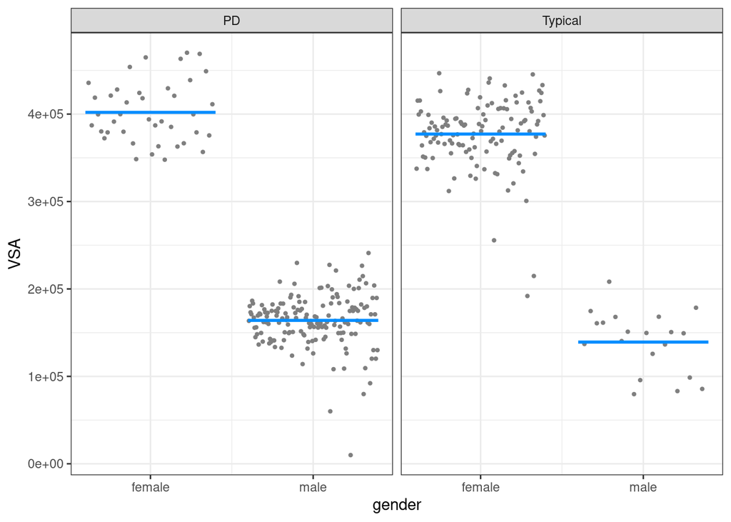

```r
visreg(m2, "Gender", by="group", ylab = "VSA", xlab = "gender", gg=TRUE) + theme_bw()
```

Add language as fixed effect

```r
summary(m3 <- lmer(VSA ~ group + Gender + lang + (1|participant.id), data = data))
```

```
## Linear mixed model fit by REML. t-tests use Satterthwaite's method [
## lmerModLmerTest]
## Formula: VSA ~ group + Gender + lang + (1 | participant.id)
##    Data: data
##
## REML criterion at convergence: 8042.5
##
## Scaled residuals:
##     Min      1Q  Median      3Q     Max
## -5.2366 -0.4932  0.0665  0.5417  2.1869
##
## Random effects:
##  Groups         Name        Variance  Std.Dev.
##  participant.id (Intercept) 4.815e+09 69393
##  Residual                   1.249e+09 35334
## Number of obs: 339, groups:  participant.id, 17
##
## Fixed effects:
##               Estimate Std. Error      df t value Pr(>|t|)
## (Intercept)     419223      44172      13   9.491 3.29e-07 ***
## groupTypical    -18739      45452      13  -0.412 0.686856
## Gendermale     -226836      45453      13  -4.991 0.000247 ***
## langSlovenian   -43542      35127      13  -1.240 0.237043
## ---
## Signif. codes:  0 '***' 0.001 '**' 0.01 '*' 0.05 '.' 0.1 ' ' 1
##
## Correlation of Fixed Effects:
##             (Intr) grpTyp Gndrml
## groupTypicl -0.729
## Gendermale  -0.729  0.653
## langSlovenn -0.314 -0.108 -0.198
```

```r
anova(m2, m3)
```

```
## refitting model(s) with ML (instead of REML)
```

```
## Data: data
## Models:
## m2: VSA ~ group + Gender + (1 | participant.id)
## m3: VSA ~ group + Gender + lang + (1 | participant.id)
##    npar    AIC    BIC  logLik deviance  Chisq Df Pr(>Chisq)
## m2    5 8143.9 8163.0 -4066.9   8133.9
## m3    6 8144.0 8166.9 -4066.0   8132.0 1.8991  1     0.1682
```

No improvement.

Add time of day as fixed effect.

```r
summary(m4 <- lmer(VSA ~ group + Gender + time + (1|participant.id), data = data))
```

```
## Linear mixed model fit by REML. t-tests use Satterthwaite's method [
## lmerModLmerTest]
## Formula: VSA ~ group + Gender + time + (1 | participant.id)
##    Data: data
##
## REML criterion at convergence: 8047.9
##
## Scaled residuals:
##     Min      1Q  Median      3Q     Max
## -5.2813 -0.5132  0.0769  0.5689  2.1366
##
## Random effects:
##  Groups         Name        Variance  Std.Dev.
##  participant.id (Intercept) 5.002e+09 70728
##  Residual                   1.251e+09 35366
## Number of obs: 339, groups:  participant.id, 17
##
## Fixed effects:
##                Estimate Std. Error         df t value Pr(>|t|)
## (Intercept)   403534.50   42793.77      14.09   9.430 1.83e-07 ***
## groupTypical  -24817.36   46045.85      14.00  -0.539 0.598374
## Gendermale   -237970.18   45401.98      14.00  -5.241 0.000125 ***
## timemorning    -2539.31    3924.22     321.00  -0.647 0.518039
## ---
## Signif. codes:  0 '***' 0.001 '**' 0.01 '*' 0.05 '.' 0.1 ' ' 1
##
## Correlation of Fixed Effects:
##             (Intr) grpTyp Gndrml
## groupTypicl -0.807
## Gendermale  -0.849  0.648
## timemorning -0.055  0.000  0.000
```

```r
anova(m2, m4)
```

```
## refitting model(s) with ML (instead of REML)
```

```
## Data: data
## Models:
## m2: VSA ~ group + Gender + (1 | participant.id)
## m4: VSA ~ group + Gender + time + (1 | participant.id)
##    npar    AIC    BIC  logLik deviance  Chisq Df Pr(>Chisq)
## m2    5 8143.9 8163.0 -4066.9   8133.9
## m4    6 8145.4 8168.4 -4066.7   8133.4 0.4197  1     0.5171
```

Add day as fixed effect.

```r
summary(m5 <- lmer(VSA ~ group + Gender + day + (1|participant.id), data = data))
```

```
## Linear mixed model fit by REML. t-tests use Satterthwaite's method [
## lmerModLmerTest]
## Formula: VSA ~ group + Gender + day + (1 | participant.id)
##    Data: data
##
## REML criterion at convergence: 8007.8
##
## Scaled residuals:
##     Min      1Q  Median      3Q     Max
## -5.3386 -0.4829  0.0586  0.5346  2.2188
##
## Random effects:
##  Groups         Name        Variance  Std.Dev.
##  participant.id (Intercept) 5.002e+09 70724
##  Residual                   1.250e+09 35360
## Number of obs: 339, groups:  participant.id, 17
##
## Fixed effects:
##                Estimate Std. Error         df t value Pr(>|t|)
## (Intercept)   405516.34   42855.50      14.17   9.462 1.67e-07 ***
## groupTypical  -24803.09   46043.59      14.00  -0.539 0.598564
## Gendermale   -237995.16   45399.76      14.00  -5.242 0.000125 ***
## daysecond      -4884.25    5423.98     319.00  -0.900 0.368538
## daythird       -7825.42    5440.90     319.00  -1.438 0.151341
## dayfourth      -1354.86    5423.98     319.00  -0.250 0.802910
## ---
## Signif. codes:  0 '***' 0.001 '**' 0.01 '*' 0.05 '.' 0.1 ' ' 1
##
## Correlation of Fixed Effects:
##             (Intr) grpTyp Gndrml dyscnd dythrd
## groupTypicl -0.806
## Gendermale  -0.847  0.648
## daysecond   -0.063  0.000  0.000
## daythird    -0.063  0.000  0.000  0.498
## dayfourth   -0.063  0.000  0.000  0.500  0.498
```

```r
anova(m2, m5)
```

```
## refitting model(s) with ML (instead of REML)
```

```
## Data: data
## Models:
## m2: VSA ~ group + Gender + (1 | participant.id)
## m5: VSA ~ group + Gender + day + (1 | participant.id)
##    npar    AIC    BIC  logLik deviance Chisq Df Pr(>Chisq)
## m2    5 8143.9 8163.0 -4066.9   8133.9
## m5    8 8147.3 8177.9 -4065.7   8131.3 2.546  3      0.467
```

```r
anova(m5)
```

```
## Type III Analysis of Variance Table with Satterthwaite's method
##            Sum Sq    Mean Sq NumDF DenDF F value    Pr(>F)
## group  3.6283e+08 3.6283e+08     1    14  0.2902 0.5985644
## Gender 3.4360e+10 3.4360e+10     1    14 27.4808 0.0001246 ***
## day    3.1659e+09 1.0553e+09     3   319  0.8440 0.4706078
## ---
## Signif. codes:  0 '***' 0.001 '**' 0.01 '*' 0.05 '.' 0.1 ' ' 1
```

No improvement.

Add age as fixed effect.

```r
summary(m6 <- lmer(VSA ~ group + Gender + age + (1|participant.id), data = data))
```

```
## Linear mixed model fit by REML. t-tests use Satterthwaite's method [
## lmerModLmerTest]
## Formula: VSA ~ group + Gender + age + (1 | participant.id)
##    Data: data
##
## REML criterion at convergence: 8049.5
##
## Scaled residuals:
##     Min      1Q  Median      3Q     Max
## -5.2414 -0.4896  0.0647  0.5459  2.1844
##
## Random effects:
##  Groups         Name        Variance  Std.Dev.
##  participant.id (Intercept) 5.321e+09 72945
##  Residual                   1.249e+09 35334
## Number of obs: 339, groups:  participant.id, 17
##
## Fixed effects:
##               Estimate Std. Error        df t value Pr(>|t|)
## (Intercept)   347050.1   139942.4      13.0   2.480 0.027608 *
## groupTypical  -23797.7    47535.1      13.0  -0.501 0.624997
## Gendermale   -239754.6    47004.6      13.0  -5.101 0.000204 ***
## age              874.1     2112.7      13.0   0.414 0.685797
## ---
## Signif. codes:  0 '***' 0.001 '**' 0.01 '*' 0.05 '.' 0.1 ' ' 1
##
## Correlation of Fixed Effects:
##             (Intr) grpTyp Gndrml
## groupTypicl -0.303
## Gendermale  -0.180  0.640
## age         -0.949  0.052 -0.091
```

```r
anova(m2, m6)
```

```
## refitting model(s) with ML (instead of REML)
```

```
## Data: data
## Models:
## m2: VSA ~ group + Gender + (1 | participant.id)
## m6: VSA ~ group + Gender + age + (1 | participant.id)
##    npar    AIC    BIC  logLik deviance  Chisq Df Pr(>Chisq)
## m2    5 8143.9 8163.0 -4066.9   8133.9
## m6    6 8145.6 8168.6 -4066.8   8133.6 0.2224  1     0.6372
```

No improvement.

## Interactions

Interaction between group and Gender.

```r
summary(m7 <- lmer(VSA ~ group*Gender + (1|participant.id), data = data))
```

```
## Linear mixed model fit by REML. t-tests use Satterthwaite's method [
## lmerModLmerTest]
## Formula: VSA ~ group * Gender + (1 | participant.id)
##    Data: data
##
## REML criterion at convergence: 8039.9
##
## Scaled residuals:
##     Min      1Q  Median      3Q     Max
## -5.2405 -0.4924  0.0677  0.5502  2.1847
##
## Random effects:
##  Groups         Name        Variance  Std.Dev.
##  participant.id (Intercept) 4.594e+09 67779
##  Residual                   1.249e+09 35334
## Number of obs: 339, groups:  participant.id, 17
##
## Fixed effects:
##                         Estimate Std. Error      df t value Pr(>|t|)
## (Intercept)               440053      48252      13   9.120 5.18e-07 ***
## groupTypical              -75540      55716      13  -1.356 0.198251
## Gendermale               -285533      53948      13  -5.293 0.000146 ***
## groupTypical:Gendermale   136327      91339      13   1.493 0.159425
## ---
## Signif. codes:  0 '***' 0.001 '**' 0.01 '*' 0.05 '.' 0.1 ' ' 1
##
## Correlation of Fixed Effects:
##             (Intr) grpTyp Gndrml
## groupTypicl -0.866
## Gendermale  -0.894  0.775
## grpTypcl:Gn  0.528 -0.610 -0.591
```

```r
anova(m7, m2)
```

```
## refitting model(s) with ML (instead of REML)
```

```
## Data: data
## Models:
## m2: VSA ~ group + Gender + (1 | participant.id)
## m7: VSA ~ group * Gender + (1 | participant.id)
##    npar    AIC    BIC  logLik deviance  Chisq Df Pr(>Chisq)
## m2    5 8143.9 8163.0 -4066.9   8133.9
## m7    6 8143.2 8166.1 -4065.6   8131.2 2.6888  1     0.1011
```

No improvement.

Interaction between group and language.

```r
summary(m8 <- lmer(VSA ~ group*lang + Gender + (1|participant.id), data = data))
```

```
## Linear mixed model fit by REML. t-tests use Satterthwaite's method [
## lmerModLmerTest]
## Formula: VSA ~ group * lang + Gender + (1 | participant.id)
##    Data: data
##
## REML criterion at convergence: 8017
##
## Scaled residuals:
##     Min      1Q  Median      3Q     Max
## -5.2451 -0.4863  0.0591  0.5398  2.1921
##
## Random effects:
##  Groups         Name        Variance  Std.Dev.
##  participant.id (Intercept) 4.692e+09 68499
##  Residual                   1.249e+09 35334
## Number of obs: 339, groups:  participant.id, 17
##
## Fixed effects:
##                            Estimate Std. Error      df t value Pr(>|t|)
## (Intercept)                  443286      48321      12   9.174 9.01e-07 ***
## groupTypical                 -69222      62608      12  -1.106 0.290557
## langSlovenian                -76098      44670      12  -1.704 0.114192
## Gendermale                  -232496      45141      12  -5.150 0.000241 ***
## groupTypical:langSlovenian    80206      69363      12   1.156 0.270056
## ---
## Signif. codes:  0 '***' 0.001 '**' 0.01 '*' 0.05 '.' 0.1 ' ' 1
##
## Correlation of Fixed Effects:
##             (Intr) grpTyp lngSlv Gndrml
## groupTypicl -0.772
## langSlovenn -0.492  0.380
## Gendermale  -0.701  0.541 -0.084
## grpTypcl:lS  0.431 -0.697 -0.630 -0.108
```

```r
anova(m8, m2)
```

```
## refitting model(s) with ML (instead of REML)
```

```
## Data: data
## Models:
## m2: VSA ~ group + Gender + (1 | participant.id)
## m8: VSA ~ group * lang + Gender + (1 | participant.id)
##    npar    AIC    BIC  logLik deviance  Chisq Df Pr(>Chisq)
## m2    5 8143.9 8163.0 -4066.9   8133.9
## m8    7 8144.2 8170.9 -4065.1   8130.2 3.6951  2     0.1576
```

No improvement.

Interaction between group and time.

```r
summary(m9 <- lmer(VSA ~ group*time + Gender + (1|participant.id), data = data))
```

```
## Linear mixed model fit by REML. t-tests use Satterthwaite's method [
## lmerModLmerTest]
## Formula: VSA ~ group * time + Gender + (1 | participant.id)
##    Data: data
##
## REML criterion at convergence: 8028.1
##
## Scaled residuals:
##     Min      1Q  Median      3Q     Max
## -5.2552 -0.5127  0.0725  0.5773  2.1205
##
## Random effects:
##  Groups         Name        Variance  Std.Dev.
##  participant.id (Intercept) 5.002e+09 70727
##  Residual                   1.254e+09 35418
## Number of obs: 339, groups:  participant.id, 17
##
## Fixed effects:
##                            Estimate Std. Error         df t value Pr(>|t|)
## (Intercept)               403995.38   42840.12      14.15   9.430 1.76e-07 ***
## groupTypical              -25930.53   46294.79      14.30  -0.560 0.584065
## timemorning                -3306.03    5132.50     320.00  -0.644 0.519948
## Gendermale               -237968.22   45402.17      14.00  -5.241 0.000125 ***
## groupTypical:timemorning    1853.42    7979.84     320.00   0.232 0.816483
## ---
## Signif. codes:  0 '***' 0.001 '**' 0.01 '*' 0.05 '.' 0.1 ' ' 1
##
## Correlation of Fixed Effects:
##             (Intr) grpTyp tmmrnn Gndrml
## groupTypicl -0.807
## timemorning -0.072  0.067
## Gendermale  -0.848  0.644  0.000
## grpTypcl:tm  0.046 -0.104 -0.643  0.000
```

```r
anova(m9, m2)
```

```
## refitting model(s) with ML (instead of REML)
```

```
## Data: data
## Models:
## m2: VSA ~ group + Gender + (1 | participant.id)
## m9: VSA ~ group * time + Gender + (1 | participant.id)
##    npar    AIC    BIC  logLik deviance  Chisq Df Pr(>Chisq)
## m2    5 8143.9 8163.0 -4066.9   8133.9
## m9    7 8147.4 8174.2 -4066.7   8133.4 0.4739  2      0.789
```

No improvement.

Interaction between language and time.

```r
summary(m10 <- lmer(VSA ~ group + Gender + lang*time + (1|participant.id), data = data))
```

```
## Linear mixed model fit by REML. t-tests use Satterthwaite's method [
## lmerModLmerTest]
## Formula: VSA ~ group + Gender + lang * time + (1 | participant.id)
##    Data: data
##
## REML criterion at convergence: 8003.1
##
## Scaled residuals:
##     Min      1Q  Median      3Q     Max
## -5.2244 -0.5318  0.0634  0.5867  2.1899
##
## Random effects:
##  Groups         Name        Variance  Std.Dev.
##  participant.id (Intercept) 4.815e+09 69388
##  Residual                   1.252e+09 35379
## Number of obs: 339, groups:  participant.id, 17
##
## Fixed effects:
##                             Estimate Std. Error         df t value Pr(>|t|)
## (Intercept)                423264.35   44324.49      13.18   9.549 2.73e-07 ***
## groupTypical               -18743.83   45449.78      13.00  -0.412 0.686761
## Gendermale                -226810.35   45450.32      13.00  -4.990 0.000247 ***
## langSlovenian              -47798.52   35453.44      13.49  -1.348 0.199787
## timemorning                 -6700.12    6138.08     320.00  -1.092 0.275845
## langSlovenian:timemorning    7035.84    7984.48     320.00   0.881 0.378877
## ---
## Signif. codes:  0 '***' 0.001 '**' 0.01 '*' 0.05 '.' 0.1 ' ' 1
##
## Correlation of Fixed Effects:
##             (Intr) grpTyp Gndrml lngSlv tmmrnn
## groupTypicl -0.726
## Gendermale  -0.726  0.653
## langSlovenn -0.319 -0.107 -0.196
## timemorning -0.084  0.000 -0.001  0.105
## lngSlvnn:tm  0.064  0.000  0.000 -0.136 -0.769
```

```r
anova(m2, m10)
```

```
## refitting model(s) with ML (instead of REML)
```

```
## Data: data
## Models:
## m2: VSA ~ group + Gender + (1 | participant.id)
## m10: VSA ~ group + Gender + lang * time + (1 | participant.id)
##     npar    AIC    BIC  logLik deviance  Chisq Df Pr(>Chisq)
## m2     5 8143.9 8163.0 -4066.9   8133.9
## m10    8 8146.8 8177.4 -4065.4   8130.8 3.1007  3     0.3764
```

No improvement.

Interaction between Gender and lang.

```r
summary(m11 <- lmer(VSA ~ group + Gender*lang + (1|participant.id), data = data))
```

```
## Linear mixed model fit by REML. t-tests use Satterthwaite's method [
## lmerModLmerTest]
## Formula: VSA ~ group + Gender * lang + (1 | participant.id)
##    Data: data
##
## REML criterion at convergence: 8017.7
##
## Scaled residuals:
##     Min      1Q  Median      3Q     Max
## -5.2309 -0.4963  0.0645  0.5468  2.1836
##
## Random effects:
##  Groups         Name        Variance  Std.Dev.
##  participant.id (Intercept) 4.979e+09 70563
##  Residual                   1.249e+09 35334
## Number of obs: 339, groups:  participant.id, 17
##
## Fixed effects:
##                          Estimate Std. Error      df t value Pr(>|t|)
## (Intercept)                435512      49757      12   8.753 1.48e-06 ***
## groupTypical               -22572      46483      12  -0.486  0.63600
## Gendermale                -261016      64472      12  -4.049  0.00161 **
## langSlovenian              -70371      50207      12  -1.402  0.18636
## Gendermale:langSlovenian    54301      71428      12   0.760  0.46179
## ---
## Signif. codes:  0 '***' 0.001 '**' 0.01 '*' 0.05 '.' 0.1 ' ' 1
##
## Correlation of Fixed Effects:
##             (Intr) grpTyp Gndrml lngSlv
## groupTypicl -0.701
## Gendermale  -0.772  0.541
## langSlovenn -0.505  0.000  0.389
## Gndrml:lngS  0.431 -0.108 -0.697 -0.703
```

```r
anova(m2, m11)
```

```
## refitting model(s) with ML (instead of REML)
```

```
## Data: data
## Models:
## m2: VSA ~ group + Gender + (1 | participant.id)
## m11: VSA ~ group + Gender * lang + (1 | participant.id)
##     npar    AIC    BIC  logLik deviance  Chisq Df Pr(>Chisq)
## m2     5 8143.9 8163.0 -4066.9   8133.9
## m11    7 8145.2 8171.9 -4065.6   8131.2 2.6988  2     0.2594
```

No improvement.

Interaction between Gender and age.

```r
summary(m12 <- lmer(VSA ~ group + Gender*age + (1|participant.id), data = data))
```

```
## Linear mixed model fit by REML. t-tests use Satterthwaite's method [
## lmerModLmerTest]
## Formula: VSA ~ group + Gender * age + (1 | participant.id)
##    Data: data
##
## REML criterion at convergence: 8030.5
##
## Scaled residuals:
##     Min      1Q  Median      3Q     Max
## -5.2393 -0.4856  0.0646  0.5447  2.1871
##
## Random effects:
##  Groups         Name        Variance  Std.Dev.
##  participant.id (Intercept) 5.642e+09 75116
##  Residual                   1.249e+09 35334
## Number of obs: 339, groups:  participant.id, 17
##
## Fixed effects:
##                Estimate Std. Error      df t value Pr(>|t|)
## (Intercept)      428219     213014      12   2.010   0.0674 .
## groupTypical     -31322      51049      12  -0.614   0.5510
## Gendermale      -393069     300311      12  -1.309   0.2151
## age                -344       3206      12  -0.107   0.9163
## Gendermale:age     2345       4533      12   0.517   0.6144
## ---
## Signif. codes:  0 '***' 0.001 '**' 0.01 '*' 0.05 '.' 0.1 ' ' 1
##
## Correlation of Fixed Effects:
##             (Intr) grpTyp Gndrml age
## groupTypicl -0.406
## Gendermale  -0.747  0.380
## age         -0.977  0.243  0.715
## Gendermal:g  0.737 -0.285 -0.987 -0.735
```

```r
anova(m2, m12)
```

```
## refitting model(s) with ML (instead of REML)
```

```
## Data: data
## Models:
## m2: VSA ~ group + Gender + (1 | participant.id)
## m12: VSA ~ group + Gender * age + (1 | participant.id)
##     npar    AIC  BIC  logLik deviance  Chisq Df Pr(>Chisq)
## m2     5 8143.9 8163 -4066.9   8133.9
## m12    7 8147.3 8174 -4066.6   8133.3 0.5973  2     0.7418
```

No improvement.

## Random slopes

```r
m3_randslo_group <- lmer(VSA ~ group + Gender + (1+session|participant.id), data = data,  control = lmerControl(optimizer = "bobyqa")) # fails to converge
```

```
## boundary (singular) fit: see ?isSingular
```

```r
m3_randslo_day <- lmer(VSA ~ group + Gender + (1+day|participant.id), data = data,  control = lmerControl(optimizer = "bobyqa")) # boundary (singular) fit
```

```
## boundary (singular) fit: see ?isSingular
```

No improvement.

# Check assumptions final model

```r
lme.dscore(m2, data, type="lme4")
```

```
##                       t       df          d
## groupTypical -0.5388967 14.00005 -0.2880518
## Gendermale   -5.2416170 14.00025 -2.8017366
```

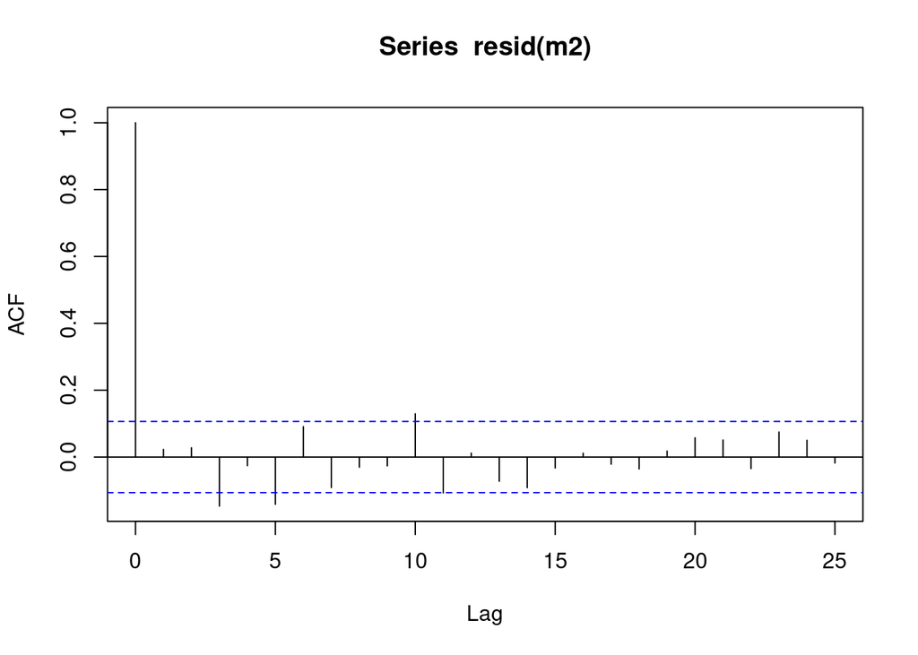

```r
acf(resid(m2)) # autocorrelation seems ok
```

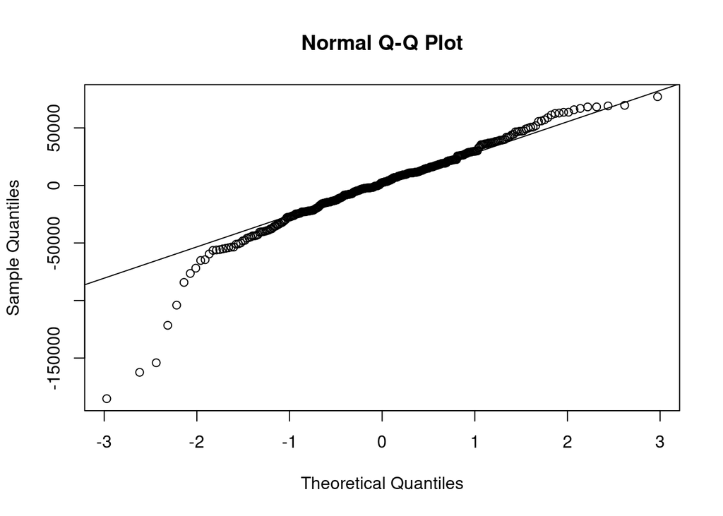

```r
qqnorm(resid(m2))
qqline(resid(m2)) # looks OKish
```

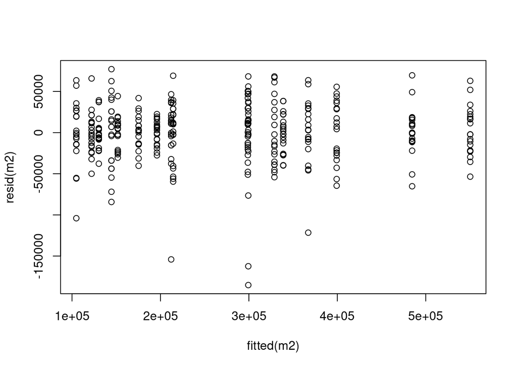

```r
plot(fitted(m2), resid(m2))
```

Looks fine.

### MODELS FOR VSA PD ONLY

Create new df with only PD:

```r
dataPD <- subset(data, group == "PD")
```

Model with only PD, state as fixed effect & random intercepts for subjects

```r
summary(m1PD <- lmer(VSA ~ state + (1|participant.id), data = dataPD))
```

```
## Linear mixed model fit by REML. t-tests use Satterthwaite's method [
## lmerModLmerTest]
## Formula: VSA ~ state + (1 | participant.id)
##    Data: dataPD
##
## REML criterion at convergence: 4706.1
##
## Scaled residuals:
##     Min      1Q  Median      3Q     Max
## -4.8518 -0.5097 -0.0093  0.5496  2.4278
##
## Random effects:
##  Groups         Name        Variance  Std.Dev.
##  participant.id (Intercept) 1.834e+10 135419
##  Residual                   1.014e+09  31845
## Number of obs: 199, groups:  participant.id, 10
##
## Fixed effects:
##             Estimate Std. Error       df t value Pr(>|t|)
## (Intercept) 212296.7    43118.2      9.2   4.924 0.000769 ***
## stateON       -837.0     5633.2    188.0  -0.149 0.882040
## ---
## Signif. codes:  0 '***' 0.001 '**' 0.01 '*' 0.05 '.' 0.1 ' ' 1
##
## Correlation of Fixed Effects:
##         (Intr)
## stateON -0.104
```

```r
summary(m1PD)
```

```
## Linear mixed model fit by REML. t-tests use Satterthwaite's method [
## lmerModLmerTest]
## Formula: VSA ~ state + (1 | participant.id)
##    Data: dataPD
##
## REML criterion at convergence: 4706.1
##
## Scaled residuals:
##     Min      1Q  Median      3Q     Max
## -4.8518 -0.5097 -0.0093  0.5496  2.4278
##
## Random effects:
##  Groups         Name        Variance  Std.Dev.
##  participant.id (Intercept) 1.834e+10 135419
##  Residual                   1.014e+09  31845
## Number of obs: 199, groups:  participant.id, 10
##
## Fixed effects:
##             Estimate Std. Error       df t value Pr(>|t|)
## (Intercept) 212296.7    43118.2      9.2   4.924 0.000769 ***
## stateON       -837.0     5633.2    188.0  -0.149 0.882040
## ---
## Signif. codes:  0 '***' 0.001 '**' 0.01 '*' 0.05 '.' 0.1 ' ' 1
##
## Correlation of Fixed Effects:
##         (Intr)
## stateON -0.104
```

No improvement.

Model with only PD, session as fixed effect & random intercepts for subjects

```r
summary(m2PD <- lmer(VSA ~ session + (1|participant.id), data = dataPD))
```

```
## Linear mixed model fit by REML. t-tests use Satterthwaite's method [
## lmerModLmerTest]
## Formula: VSA ~ session + (1 | participant.id)
##    Data: dataPD
##
## REML criterion at convergence: 4645
##
## Scaled residuals:
##     Min      1Q  Median      3Q     Max
## -4.7101 -0.5245  0.0187  0.5876  2.3272
##
## Random effects:
##  Groups         Name        Variance  Std.Dev.
##  participant.id (Intercept) 1.834e+10 135408
##  Residual                   1.014e+09  31847
## Number of obs: 199, groups:  participant.id, 10
##
## Fixed effects:
##                 Estimate Std. Error       df t value Pr(>|t|)
## (Intercept)     212296.7    43114.8      9.2   4.924 0.000769 ***
## sessionmorning1  -5302.0     7121.2    185.0  -0.745 0.457501
## sessionmorning2   -644.0     7121.2    185.0  -0.090 0.928045
## sessionevening1   6234.0     7168.9    185.0   0.870 0.385654
## sessionevening2  -3451.0     7121.2    185.0  -0.485 0.628528
## ---
## Signif. codes:  0 '***' 0.001 '**' 0.01 '*' 0.05 '.' 0.1 ' ' 1
##
## Correlation of Fixed Effects:
##             (Intr) sssnm1 sssnm2 sssnv1
## sessnmrnng1 -0.083
## sessnmrnng2 -0.083  0.500
## sessinvnng1 -0.082  0.497  0.497
## sessinvnng2 -0.083  0.500  0.500  0.497
```

```r
anova(m1PD, m2PD)
```

```
## refitting model(s) with ML (instead of REML)
```

```
## Data: dataPD
## Models:
## m1PD: VSA ~ state + (1 | participant.id)
## m2PD: VSA ~ session + (1 | participant.id)
##      npar    AIC    BIC  logLik deviance  Chisq Df Pr(>Chisq)
## m1PD    4 4756.3 4769.5 -2374.1   4748.3
## m2PD    7 4759.3 4782.3 -2372.6   4745.3 3.0178  3     0.3889
```

```r
anova(m2PD)
```

```
## Type III Analysis of Variance Table with Satterthwaite's method
##             Sum Sq   Mean Sq NumDF DenDF F value Pr(>F)
## session 3042229722 760557431     4   185  0.7499 0.5592
```

Stick with state.

Model with state and Gender as fixed effect & random intercepts for subjects

```r
summary(m3PD <- lmer(VSA ~ state + Gender + (1|participant.id), data = dataPD))
```

```
## Linear mixed model fit by REML. t-tests use Satterthwaite's method [
## lmerModLmerTest]
## Formula: VSA ~ state + Gender + (1 | participant.id)
##    Data: dataPD
##
## REML criterion at convergence: 4668.6
##
## Scaled residuals:
##     Min      1Q  Median      3Q     Max
## -4.8307 -0.5205 -0.0068  0.5684  2.4299
##
## Random effects:
##  Groups         Name        Variance  Std.Dev.
##  participant.id (Intercept) 4.331e+09 65811
##  Residual                   1.014e+09 31845
## Number of obs: 199, groups:  participant.id, 10
##
## Fixed effects:
##               Estimate Std. Error         df t value Pr(>|t|)
## (Intercept)  4.407e+05  4.702e+04  8.149e+00   9.372 1.21e-05 ***
## stateON     -8.393e+02  5.633e+03  1.880e+02  -0.149 0.881725
## Gendermale  -2.855e+05  5.233e+04  8.000e+00  -5.456 0.000604 ***
## ---
## Signif. codes:  0 '***' 0.001 '**' 0.01 '*' 0.05 '.' 0.1 ' ' 1
##
## Correlation of Fixed Effects:
##            (Intr) statON
## stateON    -0.096
## Gendermale -0.890  0.000
```

```r
anova(m1PD, m3PD)
```

```
## refitting model(s) with ML (instead of REML)
```

```
## Data: dataPD
## Models:
## m1PD: VSA ~ state + (1 | participant.id)
## m3PD: VSA ~ state + Gender + (1 | participant.id)
##      npar    AIC    BIC  logLik deviance  Chisq Df Pr(>Chisq)
## m1PD    4 4756.3 4769.5 -2374.1   4748.3
## m3PD    5 4742.8 4759.2 -2366.4   4732.8 15.521  1  8.161e-05 ***
## ---
## Signif. codes:  0 '***' 0.001 '**' 0.01 '*' 0.05 '.' 0.1 ' ' 1
```

```r
anova(m3PD)
```

```
## Type III Analysis of Variance Table with Satterthwaite's method
##            Sum Sq    Mean Sq NumDF DenDF F value    Pr(>F)
## state  2.2509e+07 2.2509e+07     1   188  0.0222 0.8817254
## Gender 3.0190e+10 3.0190e+10     1     8 29.7699 0.0006042 ***
## ---
## Signif. codes:  0 '***' 0.001 '**' 0.01 '*' 0.05 '.' 0.1 ' ' 1
```

Model 3PD has sign. lower AIC

Now we add language to the model.

```r
summary(m4PD <- lmer(VSA ~ state + Gender + lang + (1|participant.id), data = dataPD))
```

```
## Linear mixed model fit by REML. t-tests use Satterthwaite's method [
## lmerModLmerTest]
## Formula: VSA ~ state + Gender + lang + (1 | participant.id)
##    Data: dataPD
##
## REML criterion at convergence: 4642.3
##
## Scaled residuals:
##     Min      1Q  Median      3Q     Max
## -4.8098 -0.5212 -0.0003  0.5523  2.4420
##
## Random effects:
##  Groups         Name        Variance  Std.Dev.
##  participant.id (Intercept) 3.177e+09 56367
##  Residual                   1.014e+09 31845
## Number of obs: 199, groups:  participant.id, 10
##
## Fixed effects:
##                 Estimate Std. Error         df t value Pr(>|t|)
## (Intercept)    4.769e+05  4.443e+04  7.146e+00  10.734 1.15e-05 ***
## stateON       -8.351e+02  5.633e+03  1.880e+02  -0.148  0.88230
## Gendermale    -2.765e+05  4.515e+04  7.000e+00  -6.123  0.00048 ***
## langSlovenian -7.243e+04  3.687e+04  7.002e+00  -1.965  0.09021 .
## ---
## Signif. codes:  0 '***' 0.001 '**' 0.01 '*' 0.05 '.' 0.1 ' ' 1
##
## Correlation of Fixed Effects:
##             (Intr) statON Gndrml
## stateON     -0.101
## Gendermale  -0.762  0.000
## langSlovenn -0.415  0.000 -0.102
```

```r
anova(m3PD, m4PD)
```

```
## refitting model(s) with ML (instead of REML)
```

```
## Data: dataPD
## Models:
## m3PD: VSA ~ state + Gender + (1 | participant.id)
## m4PD: VSA ~ state + Gender + lang + (1 | participant.id)
##      npar    AIC    BIC  logLik deviance  Chisq Df Pr(>Chisq)
## m3PD    5 4742.8 4759.2 -2366.4   4732.8
## m4PD    6 4740.4 4760.1 -2364.2   4728.4 4.3911  1    0.03613 *
## ---
## Signif. codes:  0 '***' 0.001 '**' 0.01 '*' 0.05 '.' 0.1 ' ' 1
```

The model including language has a sign. lower AIC, but effect is not sign. when fitted with REML.

Add day to the model.

```r
summary(m5PD <- lmer(VSA ~ state + Gender + day + (1|participant.id), data = dataPD))
```

```
## Linear mixed model fit by REML. t-tests use Satterthwaite's method [
## lmerModLmerTest]
## Formula: VSA ~ state + Gender + day + (1 | participant.id)
##    Data: dataPD
##
## REML criterion at convergence: 4610
##
## Scaled residuals:
##     Min      1Q  Median      3Q     Max
## -4.7610 -0.5522 -0.0139  0.5460  2.4643
##
## Random effects:
##  Groups         Name        Variance  Std.Dev.
##  participant.id (Intercept) 4.330e+09 65803
##  Residual                   1.024e+09 32000
## Number of obs: 199, groups:  participant.id, 10
##
## Fixed effects:
##               Estimate Std. Error         df t value Pr(>|t|)
## (Intercept)  4.400e+05  4.719e+04  8.264e+00   9.326 1.15e-05 ***
## stateON     -8.527e+02  5.661e+03  1.850e+02  -0.151 0.880432
## Gendermale  -2.855e+05  5.233e+04  8.000e+00  -5.457 0.000604 ***
## daysecond   -7.783e+02  6.400e+03  1.850e+02  -0.122 0.903345
## daythird    -1.338e+03  6.434e+03  1.850e+02  -0.208 0.835466
## dayfourth    4.894e+03  6.400e+03  1.850e+02   0.765 0.445443
## ---
## Signif. codes:  0 '***' 0.001 '**' 0.01 '*' 0.05 '.' 0.1 ' ' 1
##
## Correlation of Fixed Effects:
##            (Intr) statON Gndrml dyscnd dythrd
## stateON    -0.096
## Gendermale -0.887  0.000
## daysecond  -0.068  0.000  0.000
## daythird   -0.068  0.004  0.000  0.497
## dayfourth  -0.068  0.000  0.000  0.500  0.497
```

```r
anova(m3PD, m5PD)
```

```
## refitting model(s) with ML (instead of REML)
```

```
## Data: dataPD
## Models:
## m3PD: VSA ~ state + Gender + (1 | participant.id)
## m5PD: VSA ~ state + Gender + day + (1 | participant.id)
##      npar    AIC    BIC  logLik deviance  Chisq Df Pr(>Chisq)
## m3PD    5 4742.8 4759.2 -2366.4   4732.8
## m5PD    8 4747.6 4773.9 -2365.8   4731.6 1.2101  3     0.7506
```

```r
anova(m5PD)
```

```
## Type III Analysis of Variance Table with Satterthwaite's method
##            Sum Sq    Mean Sq NumDF DenDF F value    Pr(>F)
## state  2.3233e+07 2.3233e+07     1   185  0.0227 0.8804317
## Gender 3.0490e+10 3.0490e+10     1     8 29.7764 0.0006038 ***
## day    1.2165e+09 4.0551e+08     3   185  0.3960 0.7560193
## ---
## Signif. codes:  0 '***' 0.001 '**' 0.01 '*' 0.05 '.' 0.1 ' ' 1
```

Day does not improve the fit.

Add time of day to the model.

```r
summary(m6PD <- lmer(VSA ~ state + Gender + time + (1|participant.id), data = dataPD))
```

```
## Linear mixed model fit by REML. t-tests use Satterthwaite's method [
## lmerModLmerTest]
## Formula: VSA ~ state + Gender + time + (1 | participant.id)
##    Data: dataPD
##
## REML criterion at convergence: 4649
##
## Scaled residuals:
##     Min      1Q  Median      3Q     Max
## -4.7598 -0.5359  0.0234  0.5848  2.3606
##
## Random effects:
##  Groups         Name        Variance  Std.Dev.
##  participant.id (Intercept) 4.332e+09 65815
##  Residual                   1.016e+09 31868
## Number of obs: 199, groups:  participant.id, 10
##
## Fixed effects:
##               Estimate Std. Error         df t value Pr(>|t|)
## (Intercept)  4.450e+05  4.730e+04  8.337e+00   9.409 1.01e-05 ***
## stateON     -2.973e+03  6.171e+03  1.870e+02  -0.482 0.630555
## Gendermale  -2.855e+05  5.234e+04  8.000e+00  -5.456 0.000605 ***
## timemorning -4.296e+03  5.056e+03  1.870e+02  -0.850 0.396578
## ---
## Signif. codes:  0 '***' 0.001 '**' 0.01 '*' 0.05 '.' 0.1 ' ' 1
##
## Correlation of Fixed Effects:
##             (Intr) statON Gndrml
## stateON     -0.130
## Gendermale  -0.885  0.000
## timemorning -0.107  0.407  0.000
```

```r
anova(m3PD, m6PD)
```

```
## refitting model(s) with ML (instead of REML)
```

```
## Data: dataPD
## Models:
## m3PD: VSA ~ state + Gender + (1 | participant.id)
## m6PD: VSA ~ state + Gender + time + (1 | participant.id)
##      npar    AIC    BIC  logLik deviance Chisq Df Pr(>Chisq)
## m3PD    5 4742.8 4759.2 -2366.4   4732.8
## m6PD    6 4744.0 4763.8 -2366.0   4732.0 0.728  1     0.3935
```

No improvement.

Add levodopa

```r
summary(m7PD <- lmer(VSA ~ state + Gender + levodopa + (1|participant.id), data = dataPD))
```

```
## Linear mixed model fit by REML. t-tests use Satterthwaite's method [
## lmerModLmerTest]
## Formula: VSA ~ state + Gender + levodopa + (1 | participant.id)
##    Data: dataPD
##
## REML criterion at convergence: 4657.6
##
## Scaled residuals:
##     Min      1Q  Median      3Q     Max
## -4.8347 -0.5174 -0.0054  0.5632  2.4349
##
## Random effects:
##  Groups         Name        Variance  Std.Dev.
##  participant.id (Intercept) 4.640e+09 68116
##  Residual                   1.014e+09 31845
## Number of obs: 199, groups:  participant.id, 10
##
## Fixed effects:
##               Estimate Std. Error         df t value Pr(>|t|)
## (Intercept)  4.218e+05  5.587e+04  7.092e+00   7.549 0.000123 ***
## stateON     -8.380e+02  5.633e+03  1.880e+02  -0.149 0.881897
## Gendermale  -3.050e+05  6.106e+04  7.000e+00  -4.994 0.001576 **
## levodopa     5.406e+01  7.857e+01  7.001e+00   0.688 0.513530
## ---
## Signif. codes:  0 '***' 0.001 '**' 0.01 '*' 0.05 '.' 0.1 ' ' 1
##
## Correlation of Fixed Effects:
##            (Intr) statON Gndrml
## stateON    -0.081
## Gendermale -0.460  0.000
## levodopa   -0.492  0.000 -0.462
```

```r
anova(m3PD,m7PD)
```

```
## refitting model(s) with ML (instead of REML)
```

```
## Data: dataPD
## Models:
## m3PD: VSA ~ state + Gender + (1 | participant.id)
## m7PD: VSA ~ state + Gender + levodopa + (1 | participant.id)
##      npar    AIC    BIC  logLik deviance  Chisq Df Pr(>Chisq)
## m3PD    5 4742.8 4759.2 -2366.4   4732.8
## m7PD    6 4744.1 4763.9 -2366.1   4732.1 0.6545  1     0.4185
```

No improvement.

Add diagnosis

```r
summary(m8PD <- lmer(VSA ~ state + Gender + diagnosis + (1|participant.id), data = dataPD))
```

```
## Linear mixed model fit by REML. t-tests use Satterthwaite's method [
## lmerModLmerTest]
## Formula: VSA ~ state + Gender + diagnosis + (1 | participant.id)
##    Data: dataPD
##
## REML criterion at convergence: 4645.2
##
## Scaled residuals:
##     Min      1Q  Median      3Q     Max
## -4.8573 -0.5096 -0.0037  0.5577  2.4347
##
## Random effects:
##  Groups         Name        Variance  Std.Dev.
##  participant.id (Intercept) 3.159e+09 56206
##  Residual                   1.014e+09 31845
## Number of obs: 199, groups:  participant.id, 10
##
## Fixed effects:
##               Estimate Std. Error         df t value Pr(>|t|)
## (Intercept)  3.756e+05  5.202e+04  7.106e+00   7.220 0.000162 ***
## stateON     -8.411e+02  5.633e+03  1.880e+02  -0.149 0.881466
## Gendermale  -3.466e+05  5.437e+04  7.000e+00  -6.374 0.000377 ***
## diagnosis    1.628e+04  8.220e+03  7.000e+00   1.980 0.088171 .
## ---
## Signif. codes:  0 '***' 0.001 '**' 0.01 '*' 0.05 '.' 0.1 ' ' 1
##
## Correlation of Fixed Effects:
##            (Intr) statON Gndrml
## stateON    -0.087
## Gendermale -0.209  0.000
## diagnosis  -0.632  0.000 -0.567
```

```r
anova(m3PD,m8PD)
```

```
## refitting model(s) with ML (instead of REML)
```

```
## Data: dataPD
## Models:
## m3PD: VSA ~ state + Gender + (1 | participant.id)
## m8PD: VSA ~ state + Gender + diagnosis + (1 | participant.id)
##      npar    AIC    BIC  logLik deviance  Chisq Df Pr(>Chisq)
## m3PD    5 4742.8 4759.2 -2366.4   4732.8
## m8PD    6 4740.3 4760.1 -2364.2   4728.3 4.4476  1    0.03495 *
## ---
## Signif. codes:  0 '***' 0.001 '**' 0.01 '*' 0.05 '.' 0.1 ' ' 1
```

```r
summary(m8PD)
```

```
## Linear mixed model fit by REML. t-tests use Satterthwaite's method [
## lmerModLmerTest]
## Formula: VSA ~ state + Gender + diagnosis + (1 | participant.id)
##    Data: dataPD
##
## REML criterion at convergence: 4645.2
##
## Scaled residuals:
##     Min      1Q  Median      3Q     Max
## -4.8573 -0.5096 -0.0037  0.5577  2.4347
##
## Random effects:
##  Groups         Name        Variance  Std.Dev.
##  participant.id (Intercept) 3.159e+09 56206
##  Residual                   1.014e+09 31845
## Number of obs: 199, groups:  participant.id, 10
##
## Fixed effects:
##               Estimate Std. Error         df t value Pr(>|t|)
## (Intercept)  3.756e+05  5.202e+04  7.106e+00   7.220 0.000162 ***
## stateON     -8.411e+02  5.633e+03  1.880e+02  -0.149 0.881466
## Gendermale  -3.466e+05  5.437e+04  7.000e+00  -6.374 0.000377 ***
## diagnosis    1.628e+04  8.220e+03  7.000e+00   1.980 0.088171 .
## ---
## Signif. codes:  0 '***' 0.001 '**' 0.01 '*' 0.05 '.' 0.1 ' ' 1
##
## Correlation of Fixed Effects:
##            (Intr) statON Gndrml
## stateON    -0.087
## Gendermale -0.209  0.000
## diagnosis  -0.632  0.000 -0.567
```

Sign improvement in model comparison, but no sign effect of predictor when fitted with REML (p=0.08).

Add age

```r
summary(m9PD <- lmer(VSA ~ state + Gender + age + (1|participant.id), data = dataPD))
```

```
## Linear mixed model fit by REML. t-tests use Satterthwaite's method [
## lmerModLmerTest]
## Formula: VSA ~ state + Gender + age + (1 | participant.id)
##    Data: dataPD
##
## REML criterion at convergence: 4650.9
##
## Scaled residuals:
##     Min      1Q  Median      3Q     Max
## -4.8338 -0.5207 -0.0059  0.5658  2.4291
##
## Random effects:
##  Groups         Name        Variance  Std.Dev.
##  participant.id (Intercept) 4.930e+09 70211
##  Residual                   1.014e+09 31845
## Number of obs: 199, groups:  participant.id, 10
##
## Fixed effects:
##               Estimate Std. Error         df t value Pr(>|t|)
## (Intercept)  4.777e+05  1.956e+05  7.012e+00   2.443   0.0445 *
## stateON     -8.398e+02  5.633e+03  1.880e+02  -0.149   0.8817
## Gendermale  -2.869e+05  5.624e+04  7.000e+00  -5.102   0.0014 **
## age         -5.565e+02  2.843e+03  7.004e+00  -0.196   0.8504
## ---
## Signif. codes:  0 '***' 0.001 '**' 0.01 '*' 0.05 '.' 0.1 ' ' 1
##
## Correlation of Fixed Effects:
##            (Intr) statON Gndrml
## stateON    -0.024
## Gendermale -0.349  0.000
## age        -0.967  0.001  0.126
```

```r
anova(m3PD,m9PD)
```

```
## refitting model(s) with ML (instead of REML)
```

```
## Data: dataPD
## Models:
## m3PD: VSA ~ state + Gender + (1 | participant.id)
## m9PD: VSA ~ state + Gender + age + (1 | participant.id)
##      npar    AIC    BIC  logLik deviance  Chisq Df Pr(>Chisq)
## m3PD    5 4742.8 4759.2 -2366.4   4732.8
## m9PD    6 4744.7 4764.5 -2366.3   4732.7 0.0546  1     0.8152
```

No improvement.

## Interactions

Add state*Gender

```r
summary(m10PD <- lmer(VSA ~ state*Gender + (1|participant.id), data = dataPD))
```

```
## Linear mixed model fit by REML. t-tests use Satterthwaite's method [
## lmerModLmerTest]
## Formula: VSA ~ state * Gender + (1 | participant.id)
##    Data: dataPD
##
## REML criterion at convergence: 4647.2
##
## Scaled residuals:
##     Min      1Q  Median      3Q     Max
## -4.8117 -0.5451  0.0095  0.5402  2.4387
##
## Random effects:
##  Groups         Name        Variance  Std.Dev.
##  participant.id (Intercept) 4.331e+09 65809
##  Residual                   1.017e+09 31890
## Number of obs: 199, groups:  participant.id, 10
##
## Fixed effects:
##                      Estimate Std. Error         df t value Pr(>|t|)
## (Intercept)         4.345e+05  4.788e+04  8.759e+00   9.075 9.58e-06 ***
## stateON             6.924e+03  1.261e+04  1.870e+02   0.549 0.583479
## Gendermale         -2.778e+05  5.353e+04  8.759e+00  -5.189 0.000625 ***
## stateON:Gendermale -9.707e+03  1.410e+04  1.870e+02  -0.689 0.491899
## ---
## Signif. codes:  0 '***' 0.001 '**' 0.01 '*' 0.05 '.' 0.1 ' ' 1
##
## Correlation of Fixed Effects:
##             (Intr) statON Gndrml
## stateON     -0.211
## Gendermale  -0.894  0.188
## sttON:Gndrm  0.188 -0.894 -0.211
```

```r
anova(m10PD, m3PD)
```

```
## refitting model(s) with ML (instead of REML)
```

```
## Data: dataPD
## Models:
## m3PD: VSA ~ state + Gender + (1 | participant.id)
## m10PD: VSA ~ state * Gender + (1 | participant.id)
##       npar    AIC    BIC  logLik deviance  Chisq Df Pr(>Chisq)
## m3PD     5 4742.8 4759.2 -2366.4   4732.8
## m10PD    6 4744.3 4764.0 -2366.1   4732.3 0.4787  1      0.489
```

No change.

Add state*language

```r
summary(m11PD <- lmer(VSA ~ state*lang + Gender + (1|participant.id), data = dataPD))
```

```
## Linear mixed model fit by REML. t-tests use Satterthwaite's method [
## lmerModLmerTest]
## Formula: VSA ~ state * lang + Gender + (1 | participant.id)
##    Data: dataPD
##
## REML criterion at convergence: 4618.3
##
## Scaled residuals:
##     Min      1Q  Median      3Q     Max
## -4.7882 -0.5379  0.0139  0.5452  2.5118
##
## Random effects:
##  Groups         Name        Variance  Std.Dev.
##  participant.id (Intercept) 3.177e+09 56365
##  Residual                   1.001e+09 31637
## Number of obs: 199, groups:  participant.id, 10
##
## Fixed effects:
##                         Estimate Std. Error         df t value Pr(>|t|)
## (Intercept)            4.667e+05  4.476e+04  7.363e+00  10.427 1.14e-05 ***
## stateON                1.199e+04  8.857e+03  1.870e+02   1.353  0.17764
## langSlovenian         -5.539e+04  3.798e+04  7.884e+00  -1.459  0.18331
## Gendermale            -2.765e+05  4.515e+04  7.000e+00  -6.124  0.00048 ***
## stateON:langSlovenian -2.134e+04  1.143e+04  1.870e+02  -1.867  0.06341 .
## ---
## Signif. codes:  0 '***' 0.001 '**' 0.01 '*' 0.05 '.' 0.1 ' ' 1
##
## Correlation of Fixed Effects:
##             (Intr) statON lngSlv Gndrml
## stateON     -0.158
## langSlovenn -0.429  0.186
## Gendermale  -0.757  0.000 -0.099
## sttON:lngSl  0.122 -0.775 -0.240  0.000
```

```r
anova(m3PD, m11PD)
```

```
## refitting model(s) with ML (instead of REML)
```

```
## Data: dataPD
## Models:
## m3PD: VSA ~ state + Gender + (1 | participant.id)
## m11PD: VSA ~ state * lang + Gender + (1 | participant.id)
##       npar    AIC    BIC  logLik deviance  Chisq Df Pr(>Chisq)
## m3PD     5 4742.8 4759.2 -2366.4   4732.8
## m11PD    7 4738.9 4761.9 -2362.4   4724.9 7.8841  2    0.01941 *
## ---
## Signif. codes:  0 '***' 0.001 '**' 0.01 '*' 0.05 '.' 0.1 ' ' 1
```

```r
summary(m11PD)
```

```
## Linear mixed model fit by REML. t-tests use Satterthwaite's method [
## lmerModLmerTest]
## Formula: VSA ~ state * lang + Gender + (1 | participant.id)
##    Data: dataPD
##
## REML criterion at convergence: 4618.3
##
## Scaled residuals:
##     Min      1Q  Median      3Q     Max
## -4.7882 -0.5379  0.0139  0.5452  2.5118
##
## Random effects:
##  Groups         Name        Variance  Std.Dev.
##  participant.id (Intercept) 3.177e+09 56365
##  Residual                   1.001e+09 31637
## Number of obs: 199, groups:  participant.id, 10
##
## Fixed effects:
##                         Estimate Std. Error         df t value Pr(>|t|)
## (Intercept)            4.667e+05  4.476e+04  7.363e+00  10.427 1.14e-05 ***
## stateON                1.199e+04  8.857e+03  1.870e+02   1.353  0.17764
## langSlovenian         -5.539e+04  3.798e+04  7.884e+00  -1.459  0.18331
## Gendermale            -2.765e+05  4.515e+04  7.000e+00  -6.124  0.00048 ***
## stateON:langSlovenian -2.134e+04  1.143e+04  1.870e+02  -1.867  0.06341 .
## ---
## Signif. codes:  0 '***' 0.001 '**' 0.01 '*' 0.05 '.' 0.1 ' ' 1
##
## Correlation of Fixed Effects:
##             (Intr) statON lngSlv Gndrml
## stateON     -0.158
## langSlovenn -0.429  0.186
## Gendermale  -0.757  0.000 -0.099
## sttON:lngSl  0.122 -0.775 -0.240  0.000
```

Sign in model comparison using ML, but effect is not sign, when using REML (p=0.06).

Add state*day interaction

```r
summary(m12PD <- lmer(VSA ~ state*day + Gender + (1|participant.id), data = dataPD))
```

```
## Linear mixed model fit by REML. t-tests use Satterthwaite's method [
## lmerModLmerTest]
## Formula: VSA ~ state * day + Gender + (1 | participant.id)
##    Data: dataPD
##
## REML criterion at convergence: 4545.8
##
## Scaled residuals:
##     Min      1Q  Median      3Q     Max
## -4.7469 -0.4857  0.0141  0.5580  2.4437
##
## Random effects:
##  Groups         Name        Variance  Std.Dev.
##  participant.id (Intercept) 4.330e+09 65801
##  Residual                   1.034e+09 32153
## Number of obs: 199, groups:  participant.id, 10
##
## Fixed effects:
##                     Estimate Std. Error         df t value Pr(>|t|)
## (Intercept)        4.485e+05  4.784e+04  8.733e+00   9.375 7.54e-06 ***
## stateON           -1.147e+04  1.137e+04  1.820e+02  -1.009 0.314500
## daysecond         -1.041e+04  1.438e+04  1.820e+02  -0.724 0.470141
## daythird          -1.250e+04  1.438e+04  1.820e+02  -0.869 0.385961
## dayfourth         -8.281e+03  1.438e+04  1.820e+02  -0.576 0.565403
## Gendermale        -2.855e+05  5.233e+04  8.000e+00  -5.457 0.000604 ***
## stateON:daysecond  1.204e+04  1.608e+04  1.820e+02   0.749 0.455017
## stateON:daythird   1.397e+04  1.610e+04  1.820e+02   0.868 0.386795
## stateON:dayfourth  1.647e+04  1.608e+04  1.820e+02   1.024 0.307019
## ---
## Signif. codes:  0 '***' 0.001 '**' 0.01 '*' 0.05 '.' 0.1 ' ' 1
##
## Correlation of Fixed Effects:
##             (Intr) statON dyscnd dythrd dyfrth Gndrml sttON:dys sttON:dyt
## stateON     -0.190
## daysecond   -0.150  0.632
## daythird    -0.150  0.632  0.500
## dayfourth   -0.150  0.632  0.500  0.500
## Gendermale  -0.875  0.000  0.000  0.000  0.000
## sttON:dyscn  0.134 -0.707 -0.894 -0.447 -0.447  0.000
## sttON:dythr  0.134 -0.706 -0.447 -0.893 -0.447  0.000  0.499
## sttON:dyfrt  0.134 -0.707 -0.447 -0.447 -0.894  0.000  0.500     0.499
```

```r
anova(m3PD, m12PD)
```

```
## refitting model(s) with ML (instead of REML)
```

```
## Data: dataPD
## Models:
## m3PD: VSA ~ state + Gender + (1 | participant.id)
## m12PD: VSA ~ state * day + Gender + (1 | participant.id)
##       npar    AIC    BIC  logLik deviance  Chisq Df Pr(>Chisq)
## m3PD     5 4742.8 4759.2 -2366.4   4732.8
## m12PD   11 4752.3 4788.5 -2365.1   4730.3 2.4924  6     0.8693
```

```r
anova(m12PD)
```

```
## Type III Analysis of Variance Table with Satterthwaite's method
##               Sum Sq    Mean Sq NumDF DenDF F value    Pr(>F)
## state     2.2991e+07 2.2991e+07     1   182  0.0222 0.8816191
## day       7.9583e+08 2.6528e+08     3   182  0.2566 0.8565618
## Gender    3.0781e+10 3.0781e+10     1     8 29.7742 0.0006039 ***
## state:day 1.2810e+09 4.2700e+08     3   182  0.4130 0.7438371
## ---
## Signif. codes:  0 '***' 0.001 '**' 0.01 '*' 0.05 '.' 0.1 ' ' 1
```

No added value.

Add lang*time interaction

```r
summary(m13PD <- lmer(VSA ~ state + Gender + lang*time + (1|participant.id), data = dataPD))
```

```
## Linear mixed model fit by REML. t-tests use Satterthwaite's method [
## lmerModLmerTest]
## Formula: VSA ~ state + Gender + lang * time + (1 | participant.id)
##    Data: dataPD
##
## REML criterion at convergence: 4602.4
##
## Scaled residuals:
##     Min      1Q  Median      3Q     Max
## -4.7448 -0.5537  0.0137  0.5912  2.3930
##
## Random effects:
##  Groups         Name        Variance  Std.Dev.
##  participant.id (Intercept) 3.176e+09 56354
##  Residual                   1.020e+09 31942
## Number of obs: 199, groups:  participant.id, 10
##
## Fixed effects:
##                             Estimate Std. Error         df t value Pr(>|t|)
## (Intercept)                4.825e+05  4.485e+04  7.422e+00  10.760 8.61e-06 ***
## stateON                   -2.973e+03  6.186e+03  1.860e+02  -0.481  0.63135
## Gendermale                -2.764e+05  4.514e+04  7.000e+00  -6.124  0.00048 ***
## langSlovenian             -7.457e+04  3.730e+04  7.344e+00  -1.999  0.08385 .
## timemorning               -6.411e+03  7.646e+03  1.860e+02  -0.838  0.40288
## langSlovenian:timemorning  3.483e+03  9.468e+03  1.860e+02   0.368  0.71337
## ---
## Signif. codes:  0 '***' 0.001 '**' 0.01 '*' 0.05 '.' 0.1 ' ' 1
##
## Correlation of Fixed Effects:
##             (Intr) statON Gndrml lngSlv tmmrnn
## stateON     -0.138
## Gendermale  -0.755  0.000
## langSlovenn -0.418  0.000 -0.101
## timemorning -0.133  0.270 -0.001  0.116
## lngSlvnn:tm  0.077  0.000  0.001 -0.154 -0.749
```

```r
anova(m3PD, m13PD)
```

```
## refitting model(s) with ML (instead of REML)
```

```
## Data: dataPD
## Models:
## m3PD: VSA ~ state + Gender + (1 | participant.id)
## m13PD: VSA ~ state + Gender + lang * time + (1 | participant.id)
##       npar    AIC    BIC  logLik deviance  Chisq Df Pr(>Chisq)
## m3PD     5 4742.8 4759.2 -2366.4   4732.8
## m13PD    8 4743.5 4769.8 -2363.8   4727.5 5.2608  3     0.1537
```

No improvement.

Add Gender*language interaction

```r
data$state <- as.factor(data$state)
summary(m14PD <- lmer(VSA ~ state + Gender*lang + (1|participant.id), data = dataPD))
```

```
## Linear mixed model fit by REML. t-tests use Satterthwaite's method [
## lmerModLmerTest]
## Formula: VSA ~ state + Gender * lang + (1 | participant.id)
##    Data: dataPD
##
## REML criterion at convergence: 4611.3
##
## Scaled residuals:
##     Min      1Q  Median      3Q     Max
## -4.7682 -0.5120 -0.0002  0.5520  2.4358
##
## Random effects:
##  Groups         Name        Variance  Std.Dev.
##  participant.id (Intercept) 1.285e+09 35842
##  Residual                   1.014e+09 31845
## Number of obs: 199, groups:  participant.id, 10
##
## Fixed effects:
##                            Estimate Std. Error         df t value Pr(>|t|)
## (Intercept)               5.528e+05  3.682e+04  6.184e+00  15.014 4.25e-06 ***
## stateON                  -8.379e+02  5.633e+03  1.880e+02  -0.149 0.881915
## Gendermale               -3.776e+05  4.220e+04  6.002e+00  -8.949 0.000108 ***
## langSlovenian            -2.242e+05  5.168e+04  6.000e+00  -4.338 0.004886 **
## Gendermale:langSlovenian  1.922e+05  5.816e+04  6.001e+00   3.305 0.016307 *
## ---
## Signif. codes:  0 '***' 0.001 '**' 0.01 '*' 0.05 '.' 0.1 ' ' 1
##
## Correlation of Fixed Effects:
##             (Intr) statON Gndrml lngSlv
## stateON     -0.122
## Gendermale  -0.859  0.000
## langSlovenn -0.702  0.000  0.612
## Gndrml:lngS  0.624  0.000 -0.726 -0.888
```

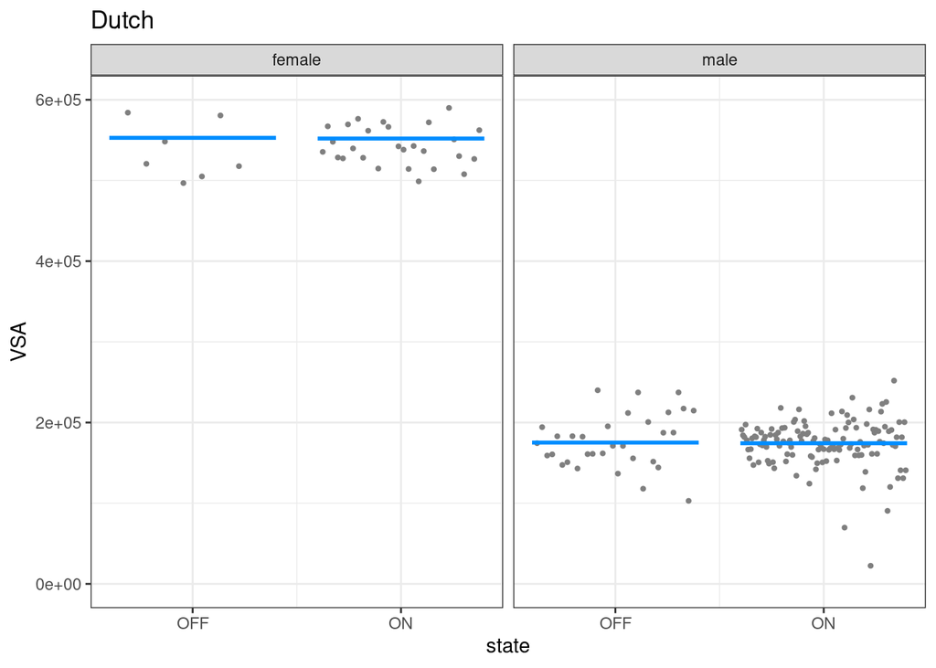

```r
visreg(m14PD, "state", "Gender", xlab="state", ylab="VSA", gg=TRUE, cond=list(lang = "Dutch")) + ggtitle("Dutch") + ylim(0,600000) + theme_bw()
```

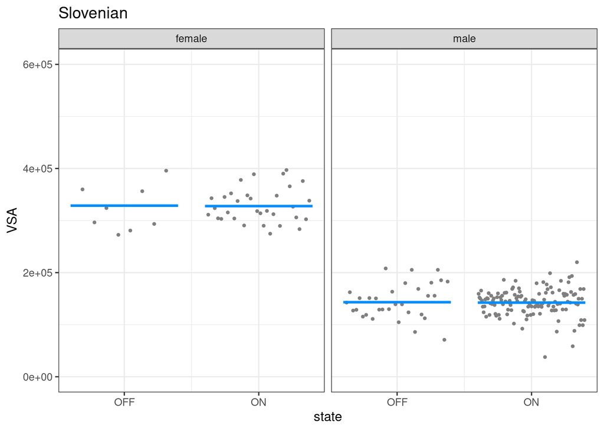

```r
visreg(m14PD, "state", "Gender", xlab="state", ylab="VSA", gg=TRUE, ylim=c(0,6000000), cond=list(lang = "Slovenian")) + ylim(0,600000) + ggtitle("Slovenian")+ theme_bw()
```

```r
anova(m3PD, m14PD)
```

```
## refitting model(s) with ML (instead of REML)
```

```
## Data: dataPD
## Models:
## m3PD: VSA ~ state + Gender + (1 | participant.id)
## m14PD: VSA ~ state + Gender * lang + (1 | participant.id)
##       npar    AIC    BIC  logLik deviance  Chisq Df Pr(>Chisq)
## m3PD     5 4742.8 4759.2 -2366.4   4732.8
## m14PD    7 4732.0 4755.1 -2359.0   4718.0 14.759  2   0.000624 ***
## ---
## Signif. codes:  0 '***' 0.001 '**' 0.01 '*' 0.05 '.' 0.1 ' ' 1
```

```r
anova(m14PD)
```

```
## Type III Analysis of Variance Table with Satterthwaite's method
##                 Sum Sq    Mean Sq NumDF   DenDF F value   Pr(>F)
## state       2.2437e+07 2.2437e+07     1 188.003  0.0221 0.881915
## Gender      9.5038e+10 9.5038e+10     1   6.001 93.7164 6.96e-05 ***
## lang        1.9665e+10 1.9665e+10     1   6.001 19.3915 0.004549 **
## Gender:lang 1.1075e+10 1.1075e+10     1   6.001 10.9212 0.016307 *
## ---
## Signif. codes:  0 '***' 0.001 '**' 0.01 '*' 0.05 '.' 0.1 ' ' 1
```

Significant, but not reliable since there was only one female in the Dutch sample.

Add language*age interaction

```r
summary(m15PD <- lmer(VSA ~ state + Gender + lang*age + (1|participant.id), data = dataPD))
```

```
## Linear mixed model fit by REML. t-tests use Satterthwaite's method [
## lmerModLmerTest]
## Formula: VSA ~ state + Gender + lang * age + (1 | participant.id)
##    Data: dataPD
##
## REML criterion at convergence: 4601.5
##
## Scaled residuals:
##     Min      1Q  Median      3Q     Max
## -4.7937 -0.5200  0.0079  0.5502  2.4261
##
## Random effects:
##  Groups         Name        Variance  Std.Dev.
##  participant.id (Intercept) 2.508e+09 50079
##  Residual                   1.014e+09 31845
## Number of obs: 199, groups:  participant.id, 10
##
## Fixed effects:
##                     Estimate Std. Error         df t value Pr(>|t|)
## (Intercept)        6.561e+05  2.150e+05  5.010e+00   3.052  0.02827 *
## stateON           -8.396e+02  5.633e+03  1.880e+02  -0.149  0.88168
## Gendermale        -3.253e+05  6.137e+04  5.000e+00  -5.301  0.00319 **
## langSlovenian      3.572e+05  5.032e+05  5.001e+00   0.710  0.50945
## age               -2.044e+03  3.319e+03  5.005e+00  -0.616  0.56483
## langSlovenian:age -7.270e+03  7.835e+03  5.001e+00  -0.928  0.39600
## ---
## Signif. codes:  0 '***' 0.001 '**' 0.01 '*' 0.05 '.' 0.1 ' ' 1
##
## Correlation of Fixed Effects:
##             (Intr) statON Gndrml lngSlv age
## stateON     -0.022
## Gendermale   0.299  0.000
## langSlovenn -0.614  0.000 -0.753
## age         -0.975  0.001 -0.477  0.715
## langSlvnn:g  0.578  0.000  0.753 -0.997 -0.686
```

```r
anova(m3PD, m15PD)
```

```
## refitting model(s) with ML (instead of REML)
```

```
## Data: dataPD
## Models:
## m3PD: VSA ~ state + Gender + (1 | participant.id)
## m15PD: VSA ~ state + Gender + lang * age + (1 | participant.id)
##       npar    AIC    BIC  logLik deviance  Chisq Df Pr(>Chisq)
## m3PD     5 4742.8 4759.2 -2366.4   4732.8
## m15PD    8 4738.7 4765.0 -2361.3   4722.7 10.079  3    0.01791 *
## ---
## Signif. codes:  0 '***' 0.001 '**' 0.01 '*' 0.05 '.' 0.1 ' ' 1
```

```r
summary(m15PD)
```

```
## Linear mixed model fit by REML. t-tests use Satterthwaite's method [
## lmerModLmerTest]
## Formula: VSA ~ state + Gender + lang * age + (1 | participant.id)
##    Data: dataPD
##
## REML criterion at convergence: 4601.5
##
## Scaled residuals:
##     Min      1Q  Median      3Q     Max
## -4.7937 -0.5200  0.0079  0.5502  2.4261
##
## Random effects:
##  Groups         Name        Variance  Std.Dev.
##  participant.id (Intercept) 2.508e+09 50079
##  Residual                   1.014e+09 31845
## Number of obs: 199, groups:  participant.id, 10
##
## Fixed effects:
##                     Estimate Std. Error         df t value Pr(>|t|)
## (Intercept)        6.561e+05  2.150e+05  5.010e+00   3.052  0.02827 *
## stateON           -8.396e+02  5.633e+03  1.880e+02  -0.149  0.88168
## Gendermale        -3.253e+05  6.137e+04  5.000e+00  -5.301  0.00319 **
## langSlovenian      3.572e+05  5.032e+05  5.001e+00   0.710  0.50945
## age               -2.044e+03  3.319e+03  5.005e+00  -0.616  0.56483
## langSlovenian:age -7.270e+03  7.835e+03  5.001e+00  -0.928  0.39600
## ---
## Signif. codes:  0 '***' 0.001 '**' 0.01 '*' 0.05 '.' 0.1 ' ' 1
##
## Correlation of Fixed Effects:
##             (Intr) statON Gndrml lngSlv age
## stateON     -0.022
## Gendermale   0.299  0.000
## langSlovenn -0.614  0.000 -0.753
## age         -0.975  0.001 -0.477  0.715
## langSlvnn:g  0.578  0.000  0.753 -0.997 -0.686
```

Sign. after model comparison but effect itself is not sign when fitted with REML.

Add state*time interaction

```r
summary(m16PD <- lmer(VSA ~ state*time + Gender + (1|participant.id), data = dataPD))
```

```
## fixed-effect model matrix is rank deficient so dropping 1 column / coefficient
```

```
## Linear mixed model fit by REML. t-tests use Satterthwaite's method [
## lmerModLmerTest]
## Formula: VSA ~ state * time + Gender + (1 | participant.id)
##    Data: dataPD
##
## REML criterion at convergence: 4649
##
## Scaled residuals:
##     Min      1Q  Median      3Q     Max
## -4.7598 -0.5359  0.0234  0.5848  2.3606
##
## Random effects:
##  Groups         Name        Variance  Std.Dev.
##  participant.id (Intercept) 4.332e+09 65815
##  Residual                   1.016e+09 31868
## Number of obs: 199, groups:  participant.id, 10
##
## Fixed effects:
##               Estimate Std. Error         df t value Pr(>|t|)
## (Intercept)  4.450e+05  4.730e+04  8.337e+00   9.409 1.01e-05 ***
## stateON     -2.973e+03  6.171e+03  1.870e+02  -0.482 0.630555
## timemorning -4.296e+03  5.056e+03  1.870e+02  -0.850 0.396578
## Gendermale  -2.855e+05  5.234e+04  8.000e+00  -5.456 0.000605 ***
## ---
## Signif. codes:  0 '***' 0.001 '**' 0.01 '*' 0.05 '.' 0.1 ' ' 1
##
## Correlation of Fixed Effects:
##             (Intr) statON tmmrnn
## stateON     -0.130
## timemorning -0.107  0.407
## Gendermale  -0.885  0.000  0.000
## fit warnings:
## fixed-effect model matrix is rank deficient so dropping 1 column / coefficient
```

```r
anova(m3PD, m16PD)
```

```
## refitting model(s) with ML (instead of REML)
```

```
## Data: dataPD
## Models:
## m3PD: VSA ~ state + Gender + (1 | participant.id)
## m16PD: VSA ~ state * time + Gender + (1 | participant.id)
##       npar    AIC    BIC  logLik deviance Chisq Df Pr(>Chisq)
## m3PD     5 4742.8 4759.2 -2366.4   4732.8
## m16PD    6 4744.0 4763.8 -2366.0   4732.0 0.728  1     0.3935
```

No improvement.

Add lang*day interaction

```r
summary(m17PD <- lmer(VSA ~ state + Gender + lang*day + (1|participant.id), data = dataPD))
```

```
## Linear mixed model fit by REML. t-tests use Satterthwaite's method [
## lmerModLmerTest]
## Formula: VSA ~ state + Gender + lang * day + (1 | participant.id)
##    Data: dataPD
##
## REML criterion at convergence: 4520.9
##
## Scaled residuals:
##     Min      1Q  Median      3Q     Max
## -4.7796 -0.5298 -0.0089  0.5141  2.3990
##
## Random effects:
##  Groups         Name        Variance  Std.Dev.
##  participant.id (Intercept) 3.178e+09 56373
##  Residual                   1.035e+09 32167
## Number of obs: 199, groups:  participant.id, 10
##
## Fixed effects:
##                           Estimate Std. Error         df t value Pr(>|t|)
## (Intercept)              4.782e+05  4.488e+04  7.433e+00  10.655 9.12e-06 ***
## stateON                 -8.656e+02  5.690e+03  1.820e+02  -0.152  0.87926
## Gendermale              -2.765e+05  4.516e+04  7.000e+00  -6.122  0.00048 ***
## langSlovenian           -7.567e+04  3.774e+04  7.681e+00  -2.005  0.08139 .
## daysecond               -5.867e+03  1.017e+04  1.820e+02  -0.577  0.56482
## daythird                -5.933e+03  1.031e+04  1.820e+02  -0.575  0.56568
## dayfourth                6.607e+03  1.017e+04  1.820e+02   0.650  0.51679
## langSlovenian:daysecond  8.481e+03  1.313e+04  1.820e+02   0.646  0.51921
## langSlovenian:daythird   7.590e+03  1.324e+04  1.820e+02   0.573  0.56718
## langSlovenian:dayfourth -2.856e+03  1.313e+04  1.820e+02  -0.217  0.82808
## ---
## Signif. codes:  0 '***' 0.001 '**' 0.01 '*' 0.05 '.' 0.1 ' ' 1
##
## Correlation of Fixed Effects:
##              (Intr) statON Gndrml lngSlv dyscnd dythrd dyfrth lngSlvnn:dys
## stateON      -0.102
## Gendermale   -0.755  0.000
## langSlovenn  -0.424  0.000 -0.100
## daysecond    -0.113  0.000  0.000  0.135
## daythird     -0.113  0.006  0.001  0.133  0.493
## dayfourth    -0.113  0.000  0.000  0.135  0.500  0.493
## lngSlvnn:dys  0.088  0.000  0.000 -0.174 -0.775 -0.382 -0.387
## lngSlvnn:dyt  0.088 -0.005 -0.001 -0.172 -0.384 -0.779 -0.384  0.496
## lngSlvnn:dyf  0.088  0.000  0.000 -0.174 -0.387 -0.382 -0.775  0.500
##              lngSlvnn:dyt
## stateON
## Gendermale
## langSlovenn
## daysecond
## daythird
## dayfourth
## lngSlvnn:dys
## lngSlvnn:dyt
## lngSlvnn:dyf  0.496
```

```r
anova(m3PD, m17PD)
```

```
## refitting model(s) with ML (instead of REML)
```

```
## Data: dataPD
## Models:
## m3PD: VSA ~ state + Gender + (1 | participant.id)
## m17PD: VSA ~ state + Gender + lang * day + (1 | participant.id)
##       npar    AIC    BIC  logLik deviance  Chisq Df Pr(>Chisq)
## m3PD     5 4742.8 4759.2 -2366.4   4732.8
## m17PD   12 4750.0 4789.6 -2363.0   4726.0 6.7187  7     0.4587
```

```r
anova(m17PD)
```

```
## Type III Analysis of Variance Table with Satterthwaite's method
##              Sum Sq    Mean Sq NumDF   DenDF F value    Pr(>F)
## state    2.3944e+07 2.3944e+07     1 182.001  0.0231 0.8792582
## Gender   3.8783e+10 3.8783e+10     1   7.000 37.4830 0.0004804 ***
## lang     3.9840e+09 3.9840e+09     1   7.002  3.8504 0.0905088 .
## day      1.6006e+09 5.3353e+08     3 182.003  0.5156 0.6720132
## lang:day 1.1212e+09 3.7374e+08     3 182.003  0.3612 0.7810850
## ---
## Signif. codes:  0 '***' 0.001 '**' 0.01 '*' 0.05 '.' 0.1 ' ' 1
```

No improvement.

## Random slopes

```r
summary(m3PDrandslo_state <- lmer(VSA ~ state + Gender + (1+state|participant.id), data = dataPD)) # singular fit
```

```
## boundary (singular) fit: see ?isSingular
```

```
## Linear mixed model fit by REML. t-tests use Satterthwaite's method [
## lmerModLmerTest]
## Formula: VSA ~ state + Gender + (1 + state | participant.id)
##    Data: dataPD
##
## REML criterion at convergence: 4667.4
##
## Scaled residuals:
##     Min      1Q  Median      3Q     Max
## -4.8761 -0.5074  0.0245  0.5409  2.4555
##
## Random effects:
##  Groups         Name        Variance  Std.Dev. Corr
##  participant.id (Intercept) 3.635e+09 60292
##                 stateON     4.289e+07  6549    1.00
##  Residual                   1.008e+09 31741
## Number of obs: 199, groups:  participant.id, 10
##
## Fixed effects:
##               Estimate Std. Error         df t value Pr(>|t|)
## (Intercept)  4.314e+05  4.383e+04  8.150e+00   9.844 8.37e-06 ***
## stateON     -8.351e+02  5.985e+03  3.313e+01  -0.140 0.889869
## Gendermale  -2.739e+05  4.893e+04  8.137e+00  -5.598 0.000481 ***
## ---
## Signif. codes:  0 '***' 0.001 '**' 0.01 '*' 0.05 '.' 0.1 ' ' 1
##
## Correlation of Fixed Effects:
##            (Intr) statON
## stateON     0.055
## Gendermale -0.893  0.000
## optimizer (nloptwrap) convergence code: 0 (OK)
## boundary (singular) fit: see ?isSingular
```

```r
summary(m3PDrandslo_time <- lmer(VSA ~ state + Gender + (1+time|participant.id), data = dataPD)) # singular fit
```

```
## boundary (singular) fit: see ?isSingular
```

```
## Linear mixed model fit by REML. t-tests use Satterthwaite's method [
## lmerModLmerTest]
## Formula: VSA ~ state + Gender + (1 + time | participant.id)
##    Data: dataPD
##
## REML criterion at convergence: 4667.3
##
## Scaled residuals:
##     Min      1Q  Median      3Q     Max
## -4.7818 -0.5291  0.0143  0.5740  2.4446
##
## Random effects:
##  Groups         Name        Variance  Std.Dev. Corr
##  participant.id (Intercept) 4.723e+09 68727
##                 timemorning 3.173e+07  5633    -1.00
##  Residual                   1.006e+09 31720
## Number of obs: 199, groups:  participant.id, 10
##
## Fixed effects:
##               Estimate Std. Error         df t value Pr(>|t|)
## (Intercept)  4.450e+05  4.339e+04  8.199e+00  10.258 5.86e-06 ***
## stateON     -1.073e+03  5.673e+03  1.764e+02  -0.189 0.850201
## Gendermale  -2.976e+05  4.847e+04  8.166e+00  -6.140 0.000255 ***
## ---
## Signif. codes:  0 '***' 0.001 '**' 0.01 '*' 0.05 '.' 0.1 ' ' 1
##
## Correlation of Fixed Effects:
##            (Intr) statON
## stateON    -0.038
## Gendermale -0.894  0.000
## optimizer (nloptwrap) convergence code: 0 (OK)
## boundary (singular) fit: see ?isSingular
```

```r
summary(m3PDrandslo_session <- lmer(VSA ~ state + Gender + (1+session|participant.id), data = dataPD)) # singular fit
```

```
## boundary (singular) fit: see ?isSingular
```

```
## Linear mixed model fit by REML. t-tests use Satterthwaite's method [
## lmerModLmerTest]
## Formula: VSA ~ state + Gender + (1 + session | participant.id)
##    Data: dataPD
##
## REML criterion at convergence: 4658.1
##
## Scaled residuals:
##     Min      1Q  Median      3Q     Max
## -4.6152 -0.5538  0.0257  0.5275  2.3005
##
## Random effects:
##  Groups         Name            Variance  Std.Dev. Corr
##  participant.id (Intercept)     3.683e+09 60690
##                 sessionmorning1 9.938e+07  9969     0.28
##                 sessionmorning2 3.656e+08 19120     0.26 -0.20
##                 sessionevening1 1.884e+08 13725     0.95  0.17  0.01
##                 sessionevening2 1.825e+08 13509     0.28 -0.52  0.93  0.11
##  Residual                       8.882e+08 29802
## Number of obs: 199, groups:  participant.id, 10
##
## Fixed effects:
##               Estimate Std. Error         df t value Pr(>|t|)
## (Intercept)  4.205e+05  3.978e+04  8.553e+00  10.569 3.36e-06 ***
## stateON     -1.709e+03  5.766e+03  2.931e+01  -0.296 0.768968
## Gendermale  -2.759e+05  4.443e+04  8.581e+00  -6.209 0.000192 ***
## ---
## Signif. codes:  0 '***' 0.001 '**' 0.01 '*' 0.05 '.' 0.1 ' ' 1
##
## Correlation of Fixed Effects:
##            (Intr) statON
## stateON     0.053
## Gendermale -0.893 -0.001
## optimizer (nloptwrap) convergence code: 0 (OK)
## boundary (singular) fit: see ?isSingular
```

Models become too complex.

# Check assumptions final model

```r
lme.dscore(m14PD, data, type="lme4")
```

```
##                                   t         df          d
## stateON                   1.5153353 245.000726  0.1936222
## Gendermale               -4.2286283   9.001495 -2.8188514
## langSlovenian            -1.0726044   8.999999 -0.7150696
## Gendermale:langSlovenian  0.5810244   9.000489  0.3873391
```

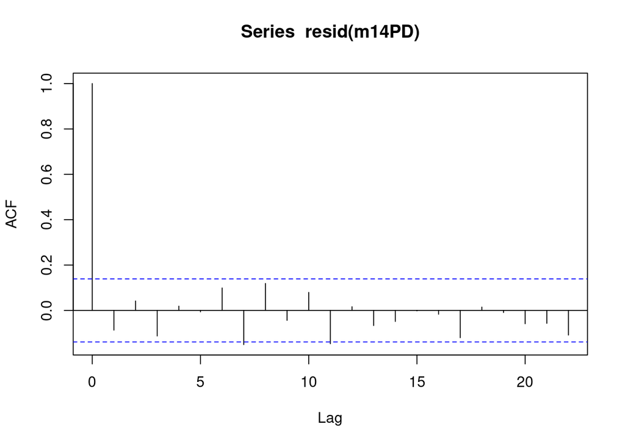

```r
acf(resid(m14PD)) # autocorrelation seems ok
```

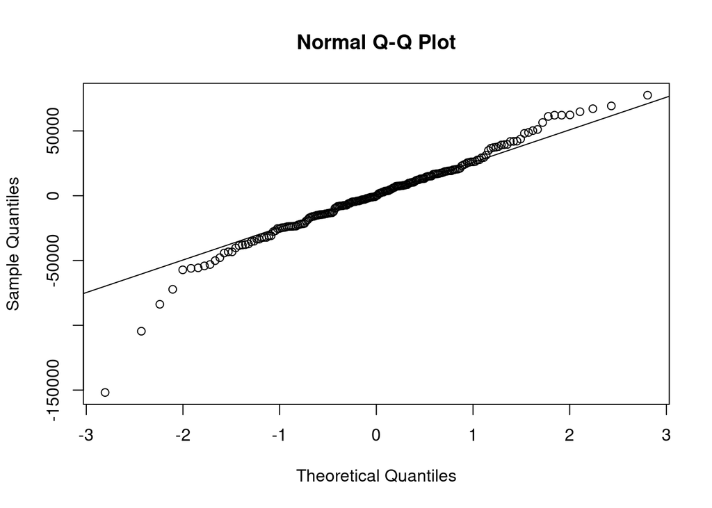

```r
qqnorm(resid(m14PD))
qqline(resid(m14PD)) # looks OK
```

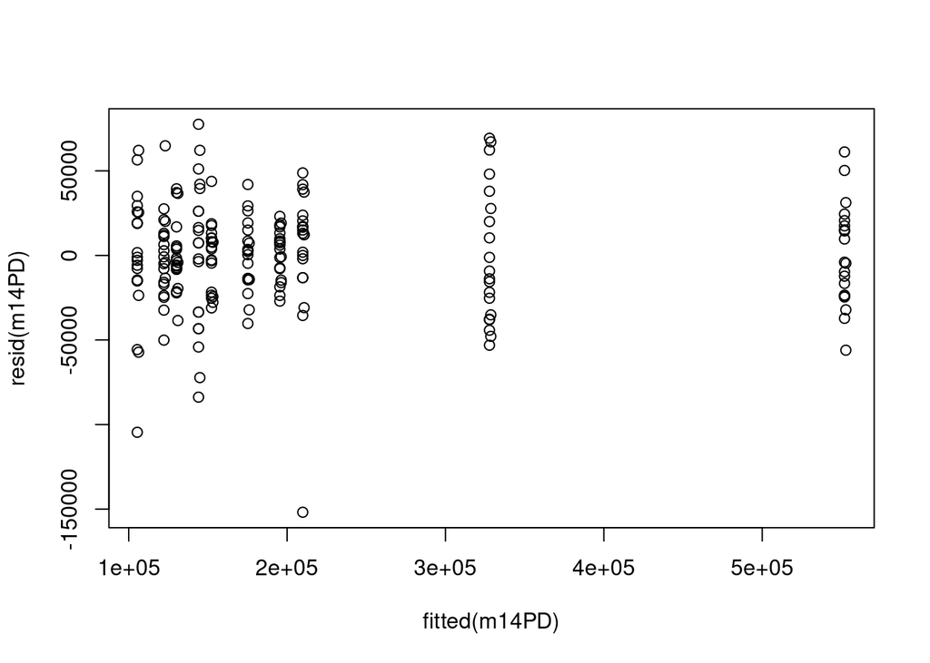

```r
plot(fitted(m14PD), resid(m14PD))
```

### Fatigue

```r
summary(m1PDf <- lmer(VSA ~ state + (1|participant.id), data = data[data$group=="PD" & data$lang == "Slovenian",]))
```

```
## Linear mixed model fit by REML. t-tests use Satterthwaite's method [
## lmerModLmerTest]
## Formula: VSA ~ state + (1 | participant.id)
##    Data: data[data$group == "PD" & data$lang == "Slovenian", ]
##
## REML criterion at convergence: 2846.9
##
## Scaled residuals:
##     Min      1Q  Median      3Q     Max
## -4.1447 -0.5141  0.0170  0.5957  2.1461
##
## Random effects:
##  Groups         Name        Variance  Std.Dev.
##  participant.id (Intercept) 7.064e+09 84046
##  Residual                   1.353e+09 36777
## Number of obs: 120, groups:  participant.id, 6
##
## Fixed effects:
##               Estimate Std. Error         df t value Pr(>|t|)
## (Intercept) 180923.955  35123.195      5.386   5.151  0.00291 **
## stateON      -9354.073   8393.205    113.000  -1.114  0.26744
## ---
## Signif. codes:  0 '***' 0.001 '**' 0.01 '*' 0.05 '.' 0.1 ' ' 1
##
## Correlation of Fixed Effects:
##         (Intr)
## stateON -0.191
```

```r
summary(m2PDf <- lmer(VSA ~ state + fatigue + (1|participant.id), data = data[data$group=="PD" & data$lang == "Slovenian",]))
```

```
## Linear mixed model fit by REML. t-tests use Satterthwaite's method [
## lmerModLmerTest]
## Formula: VSA ~ state + fatigue + (1 | participant.id)
##    Data: data[data$group == "PD" & data$lang == "Slovenian", ]
##
## REML criterion at convergence: 2829
##
## Scaled residuals:
##     Min      1Q  Median      3Q     Max
## -4.1235 -0.5101  0.0174  0.5878  2.1347
##
## Random effects:
##  Groups         Name        Variance  Std.Dev.
##  participant.id (Intercept) 7.079e+09 84137
##  Residual                   1.364e+09 36938
## Number of obs: 120, groups:  participant.id, 6
##
## Fixed effects:
##               Estimate Std. Error         df t value Pr(>|t|)
## (Intercept) 181589.893  36277.380      6.086   5.006  0.00234 **
## stateON      -9452.557   8532.280    112.106  -1.108  0.27029
## fatigue       -225.106   3011.215    114.803  -0.075  0.94054
## ---
## Signif. codes:  0 '***' 0.001 '**' 0.01 '*' 0.05 '.' 0.1 ' ' 1
##
## Correlation of Fixed Effects:
##         (Intr) statON
## stateON -0.222
## fatigue -0.246  0.154
```

```r
anova(m1PDf, m2PDf)
```

```
## refitting model(s) with ML (instead of REML)
```

```
## Data: data[data$group == "PD" & data$lang == "Slovenian", ]
## Models:
## m1PDf: VSA ~ state + (1 | participant.id)
## m2PDf: VSA ~ state + fatigue + (1 | participant.id)
##       npar    AIC    BIC  logLik deviance  Chisq Df Pr(>Chisq)
## m1PDf    4 2897.4 2908.6 -1444.7   2889.4
## m2PDf    5 2899.4 2913.4 -1444.7   2889.4 0.0063  1     0.9365
```

No improvement.

### plots

```r
data$group <- revalue(data$group, c("CTRL" = "Typical"))
```

```
## No summary function supplied, defaulting to `mean_se()`
```

```
## No summary function supplied, defaulting to `mean_se()`
## No summary function supplied, defaulting to `mean_se()`
## No summary function supplied, defaulting to `mean_se()`
```

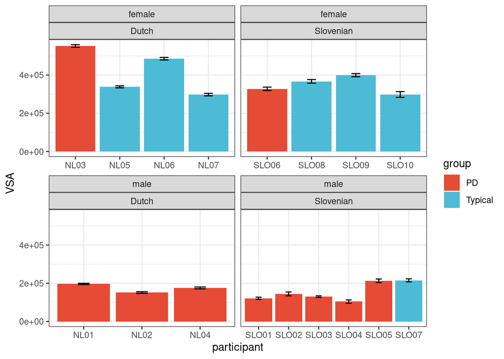

```r
         ggplot(data=data, aes(x=participant.id, y=VSA, fill=group)) +
  geom_bar(stat="summary", fun.y=mean, position='dodge') +
   stat_summary(fun.data = "mean_se", geom = 'errorbar', position=position_dodge(.9), width = 0.2) +
  facet_wrap(Gender~lang, nrow = 2, scales = "free_x") + labs(x = "participant")  +
  ggsci::scale_fill_npg() + theme_bw()
```

```
## No summary function supplied, defaulting to `mean_se()`
## No summary function supplied, defaulting to `mean_se()`
## No summary function supplied, defaulting to `mean_se()`
## No summary function supplied, defaulting to `mean_se()`
```

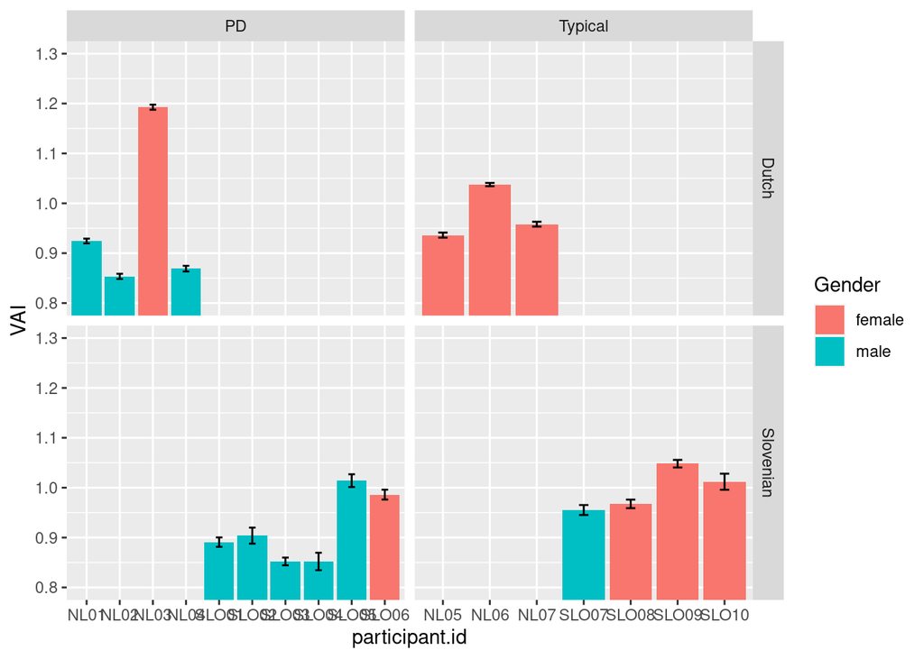

```r
ggplot(data=data, aes(x=participant.id, y=VAI, fill=Gender)) +
  geom_bar(stat="summary", fun.y=mean, position='dodge') +
   stat_summary(fun.data = "mean_se", geom = 'errorbar', position=position_dodge(.9), width = 0.2) + coord_cartesian(ylim = c(0.8, 1.3)) +
  facet_grid(lang~group,space="fixed",scales = "free_x")
```

```
## No summary function supplied, defaulting to `mean_se()`
```

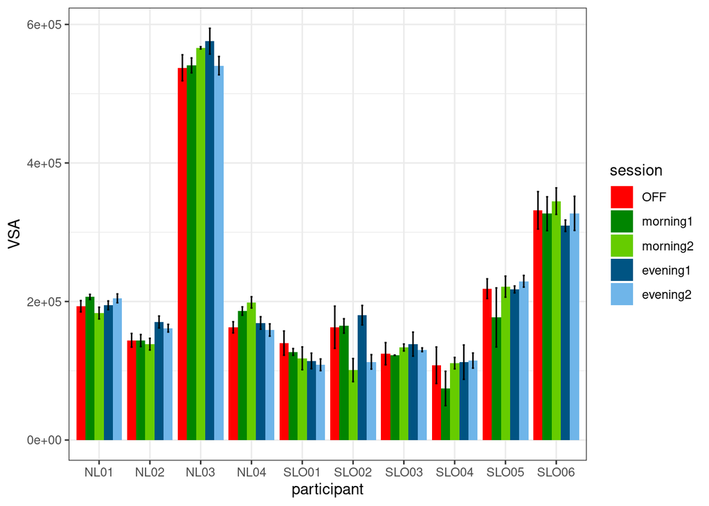

```r
ggplot(data=dataPD, aes(x=participant.id, y=VSA, fill=session)) +
  geom_bar(stat="summary", fun.y=mean, position='dodge') +
   stat_summary(fun.data = "mean_se", geom = 'errorbar', position=position_dodge(.9), width = 0.2) + scale_fill_manual(values = c("#ff0000","#008500", "#66cc00","#005483","#6fb5e9")) + labs(x = "participant") + labs(colour = "legend title") + theme_bw()
```

```
## No summary function supplied, defaulting to `mean_se()`
```

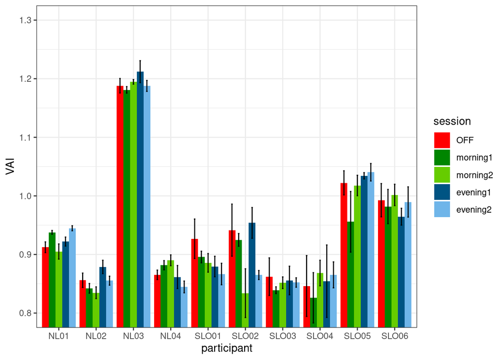

```r
ggplot(data=dataPD, aes(x=participant.id, y=VAI, fill=session)) +
  geom_bar(stat="summary", fun.y=mean, position='dodge') +
   stat_summary(fun.data = "mean_se", geom = 'errorbar', position=position_dodge(.9), width = 0.2) + scale_fill_manual(values = c("#ff0000","#008500", "#66cc00","#005483","#6fb5e9")) + coord_cartesian(ylim = c(0.8, 1.3)) + labs(x = "participant") + theme_bw()
```

```
## No summary function supplied, defaulting to `mean_se()`
```

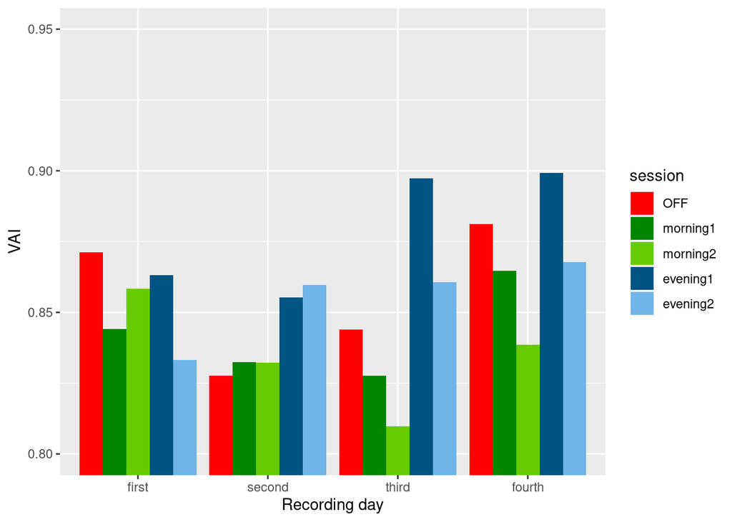

```r
#example of individual variation
ggplot(data=data[data$participant.id=="NL02",], aes(x=day, y=VAI, fill=session)) +
  geom_bar(stat="summary", fun.y=mean, position='dodge') +
   stat_summary(fun.data = "mean_se", geom = 'errorbar', position=position_dodge(.9), width = 0.2) + scale_fill_manual(values = c("#ff0000","#008500", "#66cc00","#005483","#6fb5e9")) + coord_cartesian(ylim = c(0.8, 0.95)) + labs(x = "Recording day")
```

```
## No summary function supplied, defaulting to `mean_se()`
```

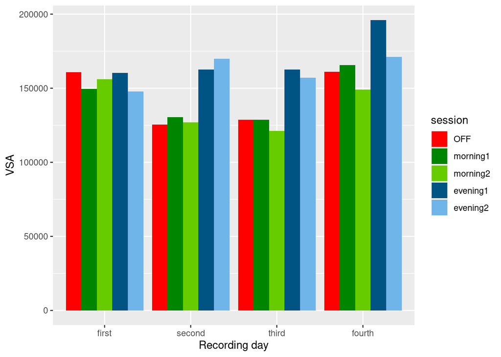

```r
#example of individual variation
ggplot(data=data[data$participant.id=="NL02",], aes(x=day, y=VSA, fill=session)) +
  geom_bar(stat="summary", fun.y=mean, position='dodge') +
   stat_summary(fun.data = "mean_se", geom = 'errorbar', position=position_dodge(.9), width = 0.2) + scale_fill_manual(values = c("#ff0000","#008500", "#66cc00","#005483","#6fb5e9")) + labs(x = "Recording day", y = "VSA")
```

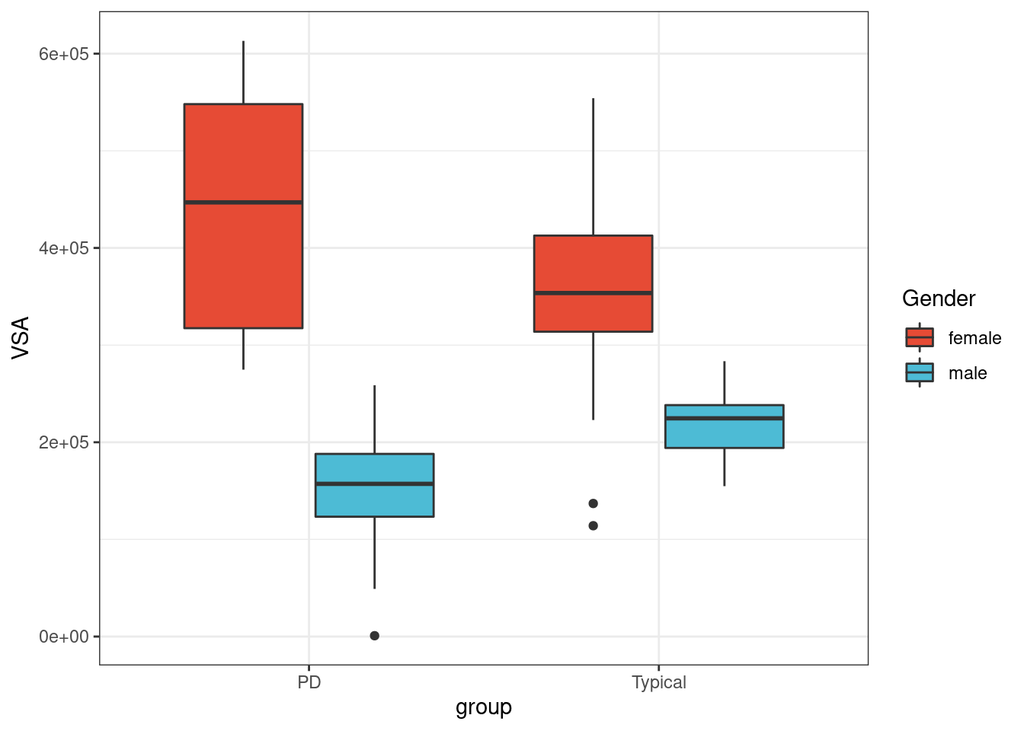

```r
ggplot(data, aes(x=group, y=VSA, fill=Gender)) + geom_boxplot() + labs(y = "VSA") + theme_bw() +
  ggsci::scale_fill_npg()
```

```
## No summary function supplied, defaulting to `mean_se()`
```

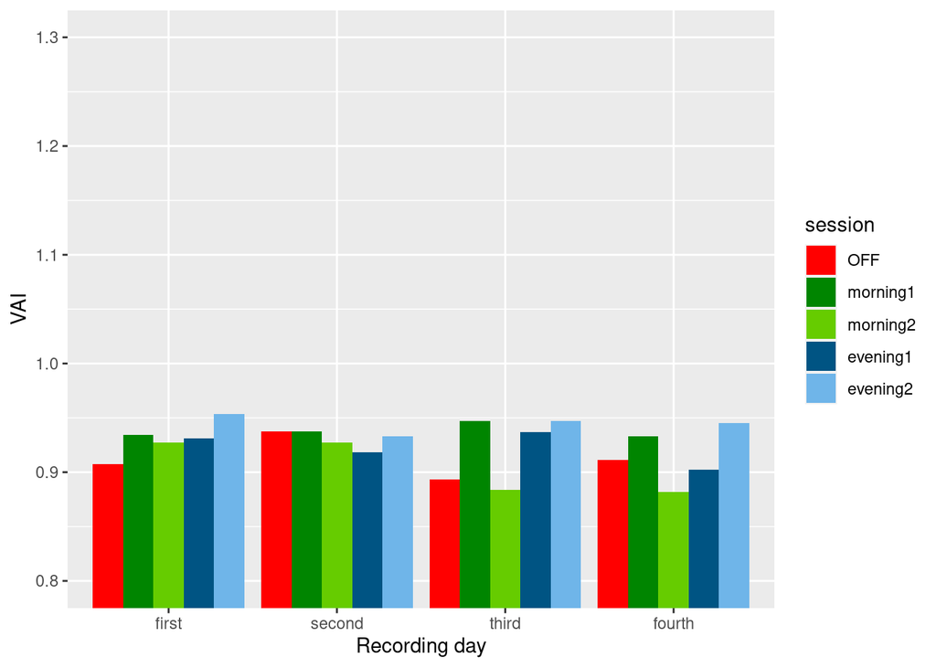

```r
### per participant ###
par(mfrow=c(4,2))

#example of individual variation
ggplot(data=data[data$participant.id=="NL01",], aes(x=day, y=VAI, fill=session)) +
  geom_bar(stat="summary", fun.y=mean, position='dodge') +
   stat_summary(fun.data = "mean_se", geom = 'errorbar', position=position_dodge(.9), width = 0.2) + scale_fill_manual(values = c("#ff0000","#008500", "#66cc00","#005483","#6fb5e9")) + coord_cartesian(ylim = c(0.8, 1.3)) + labs(x = "Recording day")
```

```
## No summary function supplied, defaulting to `mean_se()`
```

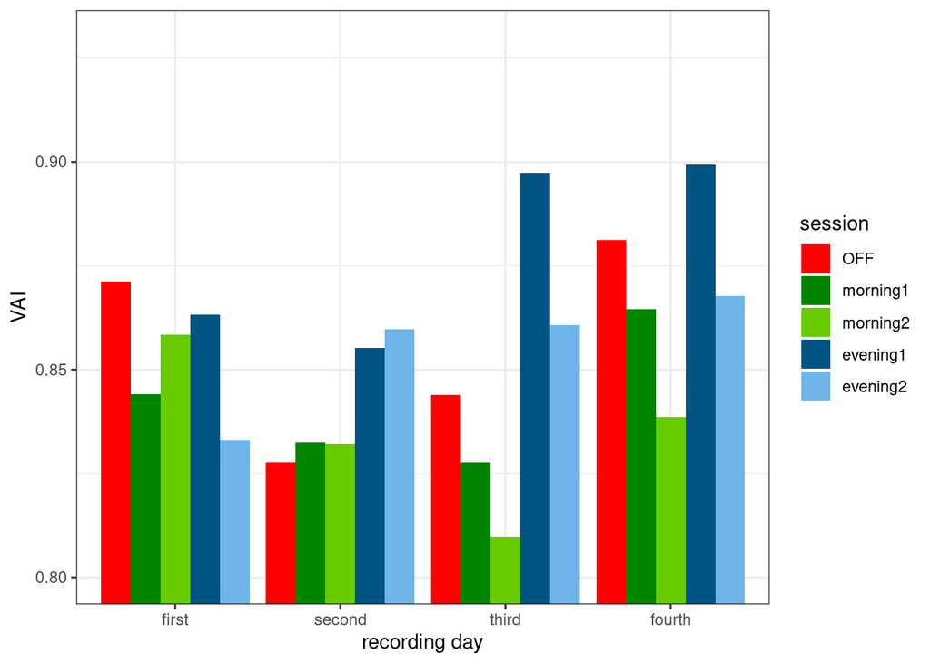

```r
#VAI
ggplot(data=data[data$participant.id=="NL02",], aes(x=day, y=VAI, fill=session)) +
  geom_bar(stat="summary", fun.y=mean, position='dodge') +
   stat_summary(fun.data = "mean_se", geom = 'errorbar', position=position_dodge(.9), width = 0.2) + scale_fill_manual(values = c("#ff0000","#008500", "#66cc00","#005483","#6fb5e9")) + coord_cartesian(ylim = c(0.8, 0.93)) + labs(x = "recording day") + theme_bw()
```

```
## No summary function supplied, defaulting to `mean_se()`
```

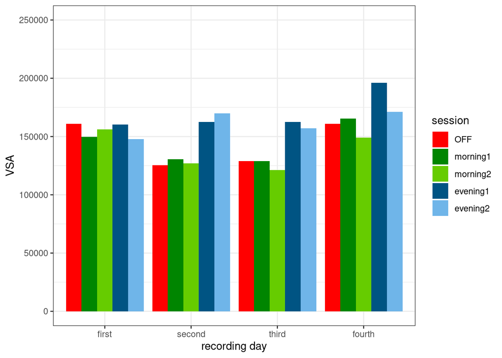

```r
#VSA
ggplot(data=data[data$participant.id=="NL02",], aes(x=day, y=VSA, fill=session)) +
  geom_bar(stat="summary", fun.y=mean, position='dodge') +
   stat_summary(fun.data = "mean_se", geom = 'errorbar', position=position_dodge(.9), width = 0.2) + scale_fill_manual(values = c("#ff0000","#008500", "#66cc00","#005483","#6fb5e9")) + coord_cartesian(ylim = c(0.8, 250000)) + labs(x = "recording day") + theme_bw()
```

```
## No summary function supplied, defaulting to `mean_se()`
```

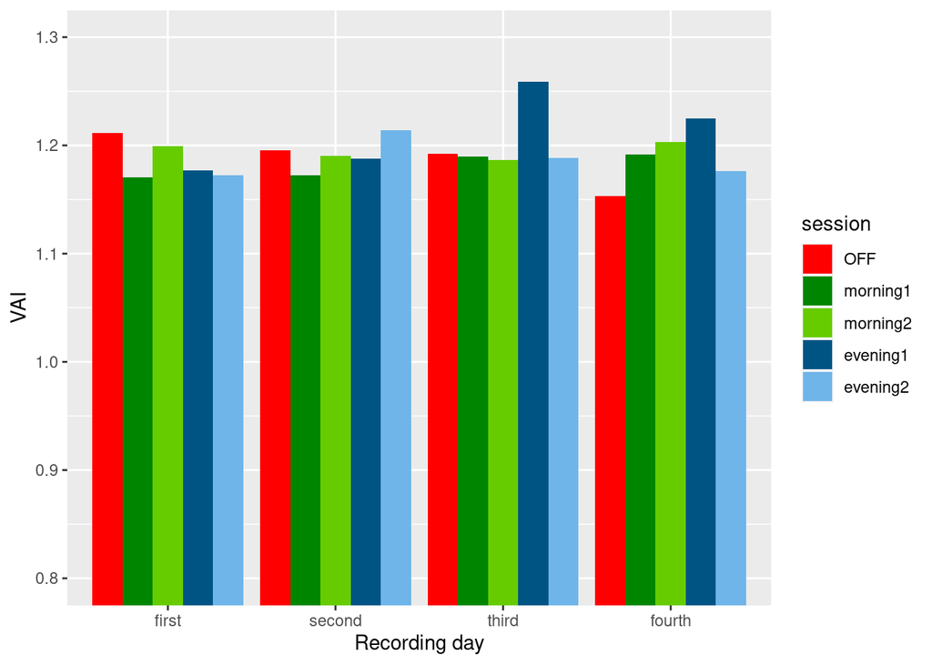

```r
#example of individual variation
ggplot(data=data[data$participant.id=="NL03",], aes(x=day, y=VAI, fill=session)) +
  geom_bar(stat="summary", fun.y=mean, position='dodge') +
   stat_summary(fun.data = "mean_se", geom = 'errorbar', position=position_dodge(.9), width = 0.2) + scale_fill_manual(values = c("#ff0000","#008500", "#66cc00","#005483","#6fb5e9")) + coord_cartesian(ylim = c(0.8, 1.3)) + labs(x = "Recording day")
```

```
## No summary function supplied, defaulting to `mean_se()`
```

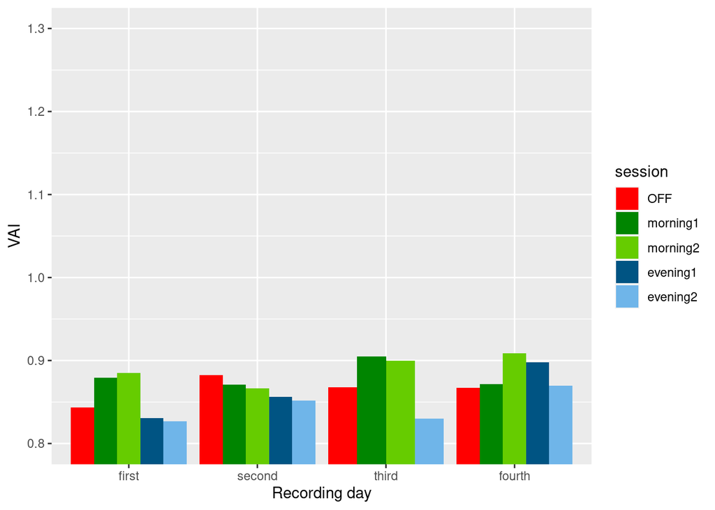

```r
#example of individual variation
ggplot(data=data[data$participant.id=="NL04",], aes(x=day, y=VAI, fill=session)) +
  geom_bar(stat="summary", fun.y=mean, position='dodge') +
   stat_summary(fun.data = "mean_se", geom = 'errorbar', position=position_dodge(.9), width = 0.2) + scale_fill_manual(values = c("#ff0000","#008500", "#66cc00","#005483","#6fb5e9")) + coord_cartesian(ylim = c(0.8, 1.3)) + labs(x = "Recording day")
```

```
## No summary function supplied, defaulting to `mean_se()`
```

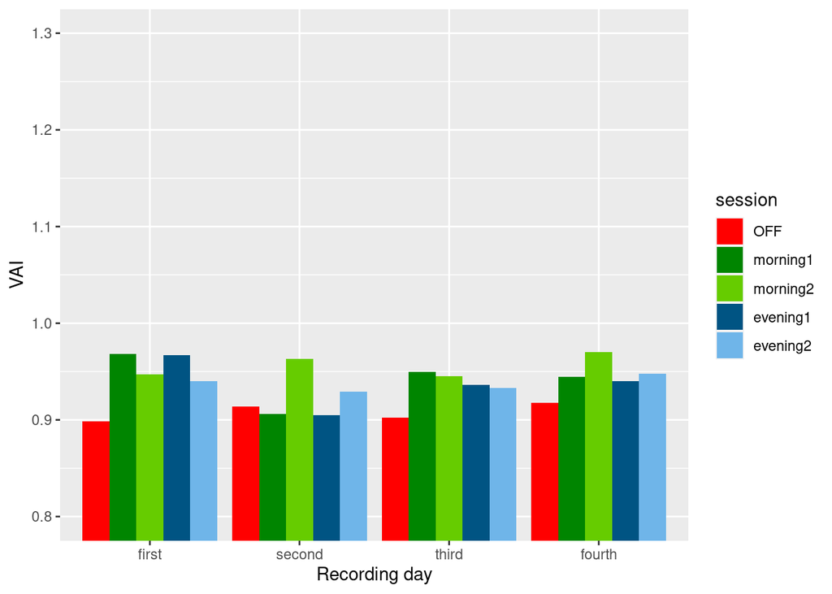

```r
#example of individual variation
ggplot(data=data[data$participant.id=="NL05",], aes(x=day, y=VAI, fill=session)) +
  geom_bar(stat="summary", fun.y=mean, position='dodge') +
   stat_summary(fun.data = "mean_se", geom = 'errorbar', position=position_dodge(.9), width = 0.2) + scale_fill_manual(values = c("#ff0000","#008500", "#66cc00","#005483","#6fb5e9")) + coord_cartesian(ylim = c(0.8, 1.3)) + labs(x = "Recording day")
```

```
## No summary function supplied, defaulting to `mean_se()`
```

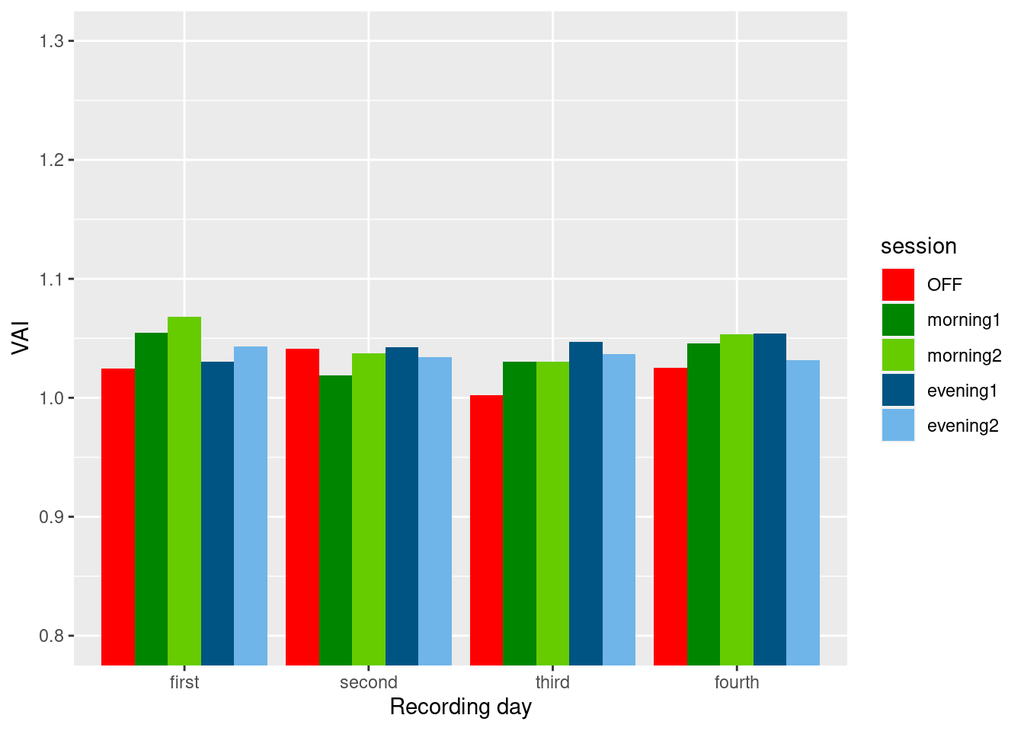

```r
#example of individual variation
ggplot(data=data[data$participant.id=="NL06",], aes(x=day, y=VAI, fill=session)) +
  geom_bar(stat="summary", fun.y=mean, position='dodge') +
   stat_summary(fun.data = "mean_se", geom = 'errorbar', position=position_dodge(.9), width = 0.2) + scale_fill_manual(values = c("#ff0000","#008500", "#66cc00","#005483","#6fb5e9")) + coord_cartesian(ylim = c(0.8, 1.3)) + labs(x = "Recording day")
```

```
## No summary function supplied, defaulting to `mean_se()`
```

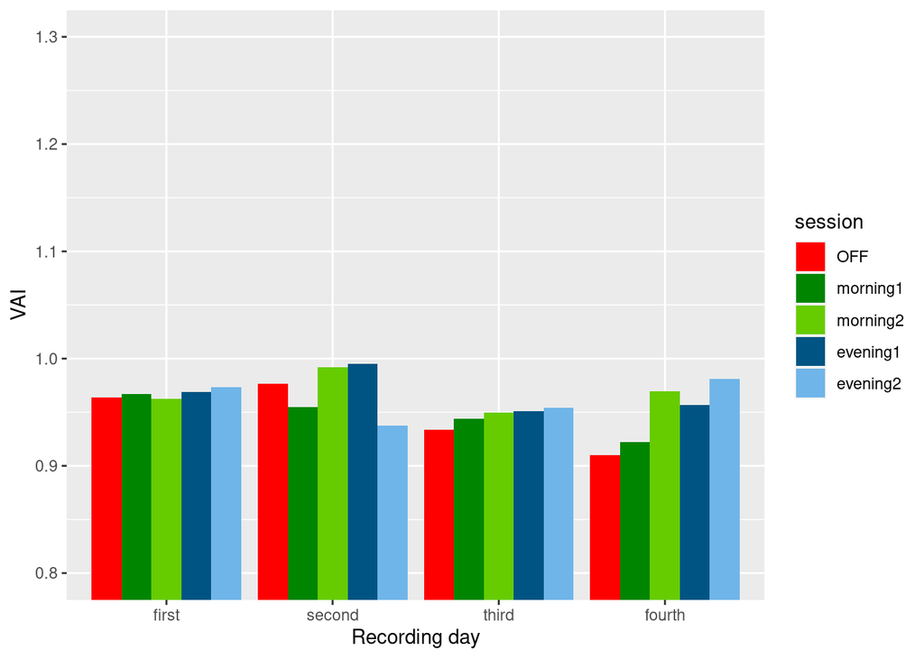

```r
#example of individual variation
ggplot(data=data[data$participant.id=="NL07",], aes(x=day, y=VAI, fill=session)) +
  geom_bar(stat="summary", fun.y=mean, position='dodge') +
   stat_summary(fun.data = "mean_se", geom = 'errorbar', position=position_dodge(.9), width = 0.2) + scale_fill_manual(values = c("#ff0000","#008500", "#66cc00","#005483","#6fb5e9")) + coord_cartesian(ylim = c(0.8, 1.3)) + labs(x = "Recording day")
```